# **Extracting Symptoms of Psychotic Disorders from Clinical Notes using Natural Language Processing.**

## **References**

### References

Aaslestad, P., Bakke, M.C.A., Ringen, P.A. and Hem, E. 2026. The patient’s voice and the writer’s role in mental health records. Tidsskrift for Den norske legeforening. Available at: https://tidsskriftet.no/en/2026/03/original-article/patients-voice-and-writers-role-mental-health-records [Accessed: 23 June 2026].

Aaslestad, P. and Skuggevik, E. 2018. The patient as text: the role of the narrator in psychiatric notes, 1890-1990. CRC Press.

Aboraya, A. et al. 2018. Measurement-based Care in Psychiatry-Past, Present, and Future. Innovations in Clinical Neuroscience 15(11–12), pp. 13–26.

Akiba, T., Sano, S., Yanase, T., Ohta, T. and Koyama, M. 2019. Optuna: A Next-Generation Hyperparameter Optimization Framework. In: The 25th ACM SIGKDD International Conference on Knowledge Discovery & Data Mining. pp. 2623–2631.

Andreasen, N.C. 1984. The Scale for the Assessment of Positive Symptoms. Iowa City, IA: University of Iowa.

Andreasen, N.C. 1989. The Scale for the Assessment of Negative Symptoms (SANS): conceptual and theoretical foundations. The British journal of psychiatry 155(S7), pp. 49–52.

Arango, C. and Carpenter, W.T. 2010. The Schizophrenia Construct: Symptomatic Presentation. In: Schizophrenia. John Wiley & Sons, Ltd, pp. 09–23. Available at: https://onlinelibrary.wiley.com/doi/abs/10.1002/9781444327298.ch2 [Accessed: 23 February 2026].

Benjamini, Y. and Hochberg, Y. 1995. Controlling the False Discovery Rate: A Practical and Powerful Approach to Multiple Testing. Journal of the Royal Statistical Society: Series B (Methodological) 57(1), pp. 289–300. doi: 10.1111/j.2517-6161.1995.tb02031.x.

Bucher, M.J.J. and Martini, M. 2024. Fine-Tuned ‘Small’ LLMs (Still) Significantly Outperform Zero-Shot Generative AI Models in Text Classification. Available at: https://arxiv.org/abs/2406.08660v2 [Accessed: 4 June 2026].

Cardno, A.G. et al. 2025. Associations of psychotic symptom dimensions with clinical and developmental variables in twin and general clinical samples. The British Journal of Psychiatry 226(1), pp. 16–23. doi: 10.1192/bjp.2024.129.

Chivilgina, O., Elger, B.S., Benichou, M.M. and Jotterand, F. 2022. “What’s the best way to document information concerning psychiatric patients? I just don’t know”—A qualitative study about recording psychiatric patients notes in the era of electronic health records. PLOS ONE 17(3), p. e0264255. doi: 10.1371/journal.pone.0264255.

Clay, B., Bergman, H.I., Salim, S., Pergola, G., Shalhoub, J. and Davies, A.H. 2025. Natural language processing techniques applied to the electronic health record in clinical research and practice - an introduction to methodologies. Computers in Biology and Medicine 188, p. 109808. doi: 10.1016/j.compbiomed.2025.109808.

Correll, C.U. and Schooler, N.R. 2020. Negative Symptoms in Schizophrenia: A Review and Clinical Guide for Recognition, Assessment, and Treatment. Neuropsychiatric Disease and Treatment 16, pp. 519–534. doi: 10.2147/NDT.S225643.

Cross, J.L., Choma, M.A. and Onofrey, J.A. 2024. Bias in medical AI: Implications for clinical decision-making. PLOS Digital Health 3(11), p. e0000651. doi: 10.1371/journal.pdig.0000651.

DeepSeek-AI. 2025. DeepSeek-R1: Incentivizing Reasoning Capability in LLMs via Reinforcement Learning. Available at: https://arxiv.org/abs/2501.12948.

Dettmers, T., Lewis, M., Belkada, Y. and Zettlemoyer, L. 2022a. LLM.int8(): 8-bit Matrix Multiplication for Transformers at Scale. arXiv preprint arXiv:2208.07339.

Dettmers, T., Lewis, M., Shleifer, S. and Zettlemoyer, L. 2022b. 8-bit Optimizers via Block-wise Quantization. 9th International Conference on Learning Representations, ICLR.

Edwards, A., Pardiñas, A.F., Kirov, G., Rees, E. and Camacho-Collados, J. 2025. Large Language Model–Supported Identification of Intellectual Disabilities in Clinical Free-Text Summaries: Mixed Methods Study. JMIR AI 4(1), p. e72256. doi: 10.2196/72256.

Edwards, P.J., Roberts, I., Clarke, M.J., DiGuiseppi, C., Woolf, B. and Perkins, C. 2023. Methods to increase response to postal and electronic questionnaires. Cochrane database of systematic reviews (11).

Endicott, J., Spitzer, R.L., Fleiss, J.L. and Cohen, J. 1976. The Global Assessment Scale: A procedure for measuring overall severity of psychiatric disturbance. Archives of general psychiatry 33(6), pp. 766–771.

Fagerland, M.W., Lydersen, S. and Laake, P. 2015. Recommended confidence intervals for two independent binomial proportions. Statistical Methods in Medical Research 24(2), pp. 224–254. doi: 10.1177/0962280211415469.

Fervaha, G., Foussias, G., Agid, O. and Remington, G. 2014. Impact of primary negative symptoms on functional outcomes in schizophrenia. European Psychiatry 29(7), pp. 449–455. doi: 10.1016/j.eurpsy.2014.01.007.

Frydman-Gani, C. et al. 2025. Large Language Models for Psychiatric Phenotype Extraction from Electronic Health Records. p. 2025.08.07.25333172. Available at: https://www.medrxiv.org/content/10.1101/2025.08.07.25333172v1 [Accessed: 17 September 2025].

Galderisi, S., Mucci, A., Buchanan, R.W. and Arango, C. 2018. Negative symptoms of schizophrenia: new developments and unanswered research questions. The Lancet Psychiatry 5(8), pp. 664–677. doi: 10.1016/S2215-0366(18)30050-6.

Grzenda, A. and Widge, A.S. 2024. Electronic health records and stratified psychiatry: bridge to precision treatment? Neuropsychopharmacology 49(1), pp. 285–290. doi: 10.1038/s41386-023-01724-y.

Hamra, G.B. 2022. Invited Commentary: Is Bias Towards the Null From Nondifferential Misclassification Wishful Thinking? American Journal of Epidemiology 191(8), pp. 1496–1497. doi: 10.1093/aje/kwac091.

Harshavardhan, H., Shetty, S., Shetty, R.P., Shetty, P.U., and Sakshi. 2025. Advancements in NLP: From Rule-Based Methods to Modern Language Models. In: 2025 IEEE International Conference on Electronics, Computing and Communication Technologies (CONECCT). pp. 1–5. Available at: https://ieeexplore.ieee.org/abstract/document/11306594 [Accessed: 17 February 2026].

Janik, R.A. 2024. Aspects of human memory and Large Language Models. Available at: http://arxiv.org/abs/2311.03839 [Accessed: 14 April 2026].

Kahn, R.S. et al. 2015. Schizophrenia. Nature Reviews Disease Primers 1(1), p. 15067. doi: 10.1038/nrdp.2015.67.

Kestenbaum, B. 2009. Misclassification. In: Kestenbaum, B. ed. Epidemiology and Biostatistics: An Introduction to Clinical Research. New York, NY: Springer, pp. 75–89. Available at: https://doi.org/10.1007/978-0-387-88433-2_8 [Accessed: 9 July 2026].

Knevel, R. and Liao, K.P. 2023. From real-world electronic health record data to real-world results using artificial intelligence. Annals of the Rheumatic Diseases 82(3), pp. 306–311. doi: 10.1136/ard-2022-222626.

Koch, E. et al. 2024. How Real-World Data Can Facilitate the Development of Precision Medicine Treatment in Psychiatry. Biological Psychiatry 96(7), pp. 543–551. doi: 10.1016/j.biopsych.2024.01.001.

Koleck, T.A., Dreisbach, C., Bourne, P.E. and Bakken, S. 2019. Natural language processing of symptoms documented in free-text narratives of electronic health records: a systematic review. Journal of the American Medical Informatics Association 26(4), pp. 364–379. doi: 10.1093/jamia/ocy173.

Kreimeyer, K. et al. 2017. Natural language processing systems for capturing and standardizing unstructured clinical information: A systematic review. Journal of Biomedical Informatics 73, pp. 14–29. doi: 10.1016/j.jbi.2017.07.012.

Kwon, W. et al. 2023. Efficient Memory Management for Large Language Model Serving with PagedAttention. Available at: http://arxiv.org/abs/2309.06180 [Accessed: 19 December 2025].

Legge, S.E. et al. 2020. Clinical indicators of treatment-resistant psychosis. The British Journal of Psychiatry 216(5), pp. 259–266. doi: 10.1192/bjp.2019.120.

Legge, S.E. et al. 2021. Associations Between Schizophrenia Polygenic Liability, Symptom Dimensions, and Cognitive Ability in Schizophrenia. JAMA Psychiatry 78(10), pp. 1143–1151. doi: 10.1001/jamapsychiatry.2021.1961.

Martins, A., and Srikumar, V. eds Proceedings of the 62nd Annual Meeting of the Association for Computational Linguistics (Volume 1: Long Papers). Bangkok, Thailand: Association for Computational Linguistics, pp. 15339–15353. Available at: https://aclanthology.org/2024.acl-long.818/ [Accessed: 14 April 2026].

Liu, H. and Zhang, Z. 2017. Logistic regression with misclassification in binary outcome variables: a method and software. Behaviormetrika 44(2), pp. 447–476. doi: 10.1007/s41237-017-0031-y.

Lynham, A.J. et al. 2023. DRAGON-Data: a platform and protocol for integrating genomic and phenotypic data across large psychiatric cohorts. BJPsych Open 9(2), pp. 1–8. doi: 10.1192/bjo.2022.636.

Madden, J.M., Lakoma, M.D., Rusinak, D., Lu, C.Y. and Soumerai, S.B. 2016. Missing clinical and behavioral health data in a large electronic health record (EHR) system. Journal of the American Medical Informatics Association 23(6), pp. 1143–1149. doi: 10.1093/jamia/ocw021.

Munzir, S.I., Hier, D.B., Oommen, C. and Carrithers, M.D. 2024. A Large Language Model Outperforms Other Computational Approaches to the High-Throughput Phenotyping of Physician Notes. AMIA … Annual Symposium proceedings. AMIA Symposium 2024, pp. 838–846.

Nasrallah, H.A. 2009. Long overdue: measurement-based psychiatric practice. Current Psychiatry 8(4), pp. 14-.

Neuhaus, J. 1999. Bias and efficiency loss due to misclassified responses in binary regression. Biometrika 86(4), pp. 843–855. doi: 10.1093/biomet/86.4.843.

Pakhomov, S., Jacobsen, S.J., Chute, C.G. and Roger, V.L. 2008. Agreement between Patient-reported Symptoms and their Documentation in the Medical Record. The American journal of managed care 14(8), pp. 530–539.

Pogue-Geile, M.F. 1989. The Prognostic Significance of Negative Symptoms in Schizophrenia. British Journal of Psychiatry 155(S7), pp. 123–127. doi: 10.1192/S0007125000291654.

Quinn, T.P. et al. 2024. A primer on the use of machine learning to distil knowledge from data in biological psychiatry. Molecular Psychiatry 29(2), pp. 387–401. doi: 10.1038/s41380-023-02334-2.

R Core Team. 2021. R: A Language and Environment for Statistical Computing. Available at: https://www.R-project.org/.

Reddy, S. 2024. Generative AI in healthcare: an implementation science informed translational path on application, integration and governance. Implementation Science 19(1), p. 27. doi: 10.1186/s13012-024-01357-9.

Salvatore, N., Wang, H. and Zhang, Q. 2025. Lost in the Middle: An Emergent Property from Information Retrieval Demands in LLMs. Available at: http://arxiv.org/abs/2510.10276 [Accessed: 14 April 2026].

Smoller, J.W. 2018. The use of electronic health records for psychiatric phenotyping and genomics. American Journal of Medical Genetics Part B: Neuropsychiatric Genetics 177(7), pp. 601–612. doi: 10.1002/ajmg.b.32548.

Tian, S. et al. 2024. Opportunities and challenges for ChatGPT and large language models in biomedicine and health. Briefings in Bioinformatics 25(1), p. bbad493. doi: 10.1093/bib/bbad493.

Van Rossum, G. and Drake, F.L. 2009. Python 3 Reference Manual. Scotts Valley, CA: CreateSpace.

Varshney, N., Raj, S., Mishra, V., Chatterjee, A., Saeidi, A., Sarkar, R. and Baral, C. 2025. Investigating and Addressing Hallucinations of LLMs in Tasks Involving Negation. In: Cao, T. et al. eds Proceedings of the 5th Workshop on Trustworthy NLP (TrustNLP 2025). Albuquerque, New Mexico: Association for Computational Linguistics, pp. 580–598. Available at: https://aclanthology.org/2025.trustnlp-main.37/ [Accessed: 10 April 2026].

Wing, J.K. et al. 1990. SCAN: Schedules for Clinical Assessment in Neuropsychiatry. Archives of General Psychiatry 47(6), pp. 589–593. doi: 10.1001/archpsyc.1990.01810180089012.

Wright, A.G.C., Ringwald, W.R., Vize, C.E., Eichstaedt, J.C., Angstadt, M., Taxali, A. and Sripada, C. 2026. Assessing personality using zero-shot generative AI scoring of brief open-ended text. Nature Human Behaviour, pp. 1–15. doi: 10.1038/s41562-025-02389-x.

## **Supplementary Methods**

### Symptom Extraction using Pretrained Language Models (PLMs)

#### Symptom Extraction using Pretrained Language Models (PLMs)

##### Data Preprocessing

Case note summaries and gold standard labels were loaded using the Hugging Face datasets library. Case note summaries were fed to a model specific AutoTokenizer, converting text data to numeric input IDs and creating an attention mask. Gold standard labels were aligned, and missing values were mapped to -100 to ensure that they are ignored during training. The output for each record was a dictionary containing input IDs, attention masks, and aligned gold-standard labels, which were then batched for training.

##### Data Splitting Strategy

Case notes were summarised by over 17 different individuals to form Case note summaries. Some case notes were summarised by more than one summariser; summariser groups were formed from these. To avoid data leakage, the dataset was split at the “summariser group” level rather than randomly. Scheme 1 (S1) data was kept separate from non-S1 data throughout the split. Thus, a patient record from the training set never appeared in the validation or test sets. The validation and test sets are split in roughly a 2:1 ratio.

##### Classification.

We used Pre-trained Language Models (PLMs), including standard models like BERT and RoBERTa, as well as clinical domain-specific variants, to make predictions from clinical notes.

We trained one independent binary classifier per clinical symptom per model. The input text was tokenised and passed through the model encoder, which produced a context-aware representation of the whole document (taken from the [CLS] token). This representation passed through a dropout layer and a linear classification head to produce a set of raw output scores (logits), one per label. Optuna (Akiba et al. 2019) was used for automated hyperparameter tuning, running 30 trials to find the best combination of learning rate, batch size, and gradient accumulation steps.

Formally, given an input text sequence $X=(x_1,x_2,…,x_n)$, the sequence was tokenized and passed through the PLM encoder to yield contextualized hidden states. We extracted the aggregate document representation $h_{pooled}∈R^d$ (typically derived from the $[CLS]$ token, where $d$ is the hidden dimension size).

To generate predictions for $L$ distinct clinical labels, $h_{pooled}$ was passed through a dropout layer and a randomly initialized linear classification head:

$$z=W⋅Dropout(h_{pooled})+b$$

where $W∈R^{(L×d)}$ and $b∈ R^L$ are the trainable weight matrix and bias, and $z$ represents the raw output logits for all labels.

##### Handling Long Clinical Documents

Clinical notes are often longer than the 512-token limit that standard models like BERT can handle. Mean-Pooling Chunking was used to handle this. The document was split into up to 8 sequential chunks, each within 512 tokens. Each chunk was processed independently by the model to produce its own logit. These chunk-level logits were then averaged to give a single document-level prediction.

Formally, the document was segmented into $K$ sequential chunks (e.g., $K$ = 8), each up to 512 tokens long. Each chunk is independently processed by the PLM to produce a chunk-level logit $z_K$. The final document-level logit $z_{final}$ is obtained via mean-pooling:

$$Z_{final} = \frac{1}{K} \sum_{k=1}^{K}
Z_{k}$$

##### Addressing Class Imbalance

Where there is class imbalance, a standard cross-entropy loss would push the model to predict the most frequent class (i.e., where ‘absent’ ratings are rare for delusions, the model would always predict ‘present’). To fix this, we replaced the standard loss with a customised Focal Loss.

##### Model Inference

During the evaluation phase, the pipeline dynamically loads the corresponding fine-tuned binary model for each specific label. The model processes the unseen test data to output raw logits ($z$).

To generate the final prediction, the logit was passed through a Sigmoid activation function to map it to a probability score between 0 and 1:

$$P(y=1 |
x)=\frac{1}{1+e^{-z}}$$

Rather than relying on a default 0.5 cut off, we used an optimal threshold ($τ$) that was dynamically calculated during the validation phase (optimized specifically for the F1-score). The final hard prediction (0 or 1) is made by comparing the probability against this optimal threshold:

$$y_{\text{pred}} =
\begin{cases}
1, & \text{if } P(y = 1 \mid x) > \tau \\
0, & \text{otherwise}
\end{cases}$$

##### Model Evaluation

The pipeline was run under two complementary experimental setups to ensure reliable results and coverage across all data points.

In the first setup, all records from the S1 summarise group were used as the training set. Records from the remaining summarise groups were then split into a validation set and a test set. The model was trained exclusively on S1 data and evaluated on the held-out non-S1 data. In the second setup, the roles were reversed. Records from all non-S1 summarise groups were used as the training set, and the S1 summarise group was used as the validation and test set.

## **Supplementary Figures**

### Supplementary Figures

#### Supplementary Figure 1

##### SF1. Distribution of gold-standard phenotypes

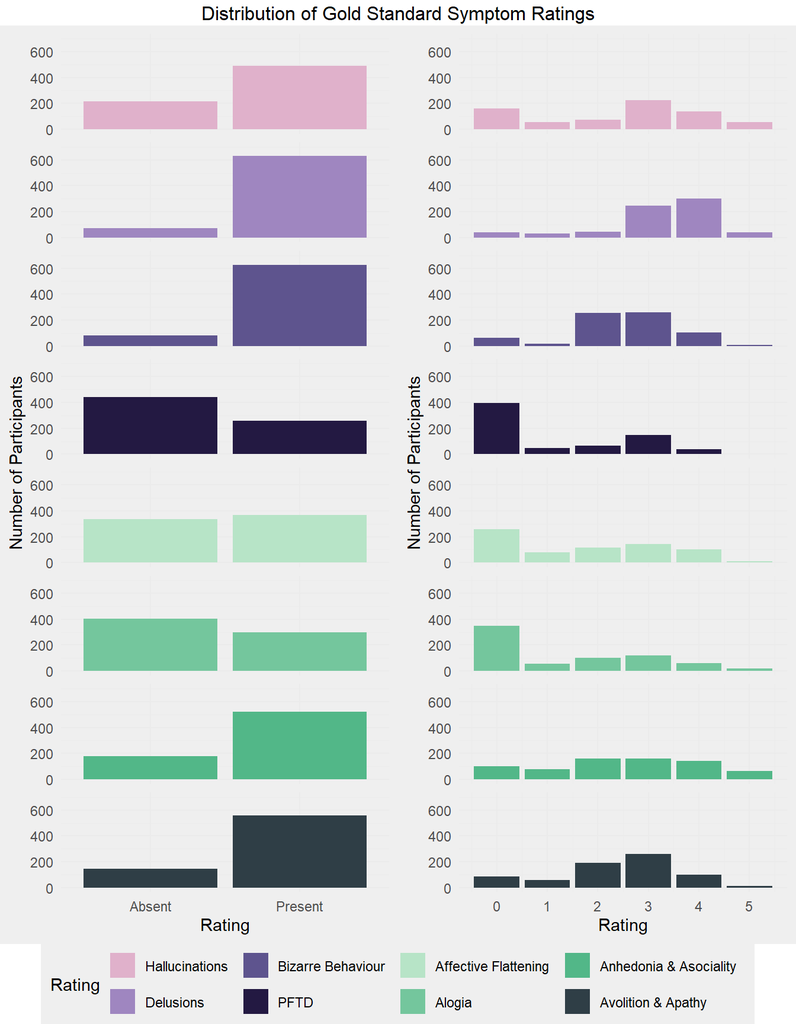

Supplementary Figure 1. Distribution of gold-standard phenotypes on the original SAPS and SANS scale, and on the binary scale used for model evaluation

```r
saps_sans_recode <- left_join(ids, saps_sans, by = "Study_ID")

saps_sans_recode <- saps_sans_recode |>
  filter(if_any(-Study_ID, ~ !is.na(.))) |>
  dplyr::select(
    "Study_ID",
    "SAPS_Global_Hals_LIFETIME",
    "SAPS_Global_Delusions_LIFETIME",
    "SAPS_Global_Positive_Thought_Disorder_LIFETIME",
    "SAPS_Global_Bizarre_Behaviour_LIFETIME",
    "SANS_Global_Affective_Flattening_LIFETIME",
    "SANS_Global_Alogia_LIFETIME",
    "SANS_Global_Avolition_Apathy_LIFETIME",
    "SANS_Global_Anhedonia_Asociality_LIFETIME"
  )

colnames(saps_sans_recode) <- c(
  "Study_ID",
  "SAPS_Global_Hals_LIFETIME",
  "SAPS_Global_Delusions_LIFETIME",
  "SAPS_Global_Positive_Thought_Disorder_LIFETIME",
  "SAPS_Global_Bizarre_Behaviour_LIFETIME",
  "SANS_Global_Affective_Flattening_LIFETIME",
  "SANS_Global_Alogia_LIFETIME",
  "SANS_Global_Avolition_Apathy_LIFETIME",
  "SANS_Global_Anhedonia_Asociality_LIFETIME"
)

saps_sans_recode <- saps_sans_recode |>
  pivot_longer(!Study_ID, names_to = "Symptom", values_to = "Rating")

# code binary
ssb <- saps_sans_recode
ssb$Rating[ssb$Rating == 0] <- 0
ssb$Rating[ssb$Rating == 1] <- 0
ssb$Rating[ssb$Rating == 2] <- 1
ssb$Rating[ssb$Rating == 3] <- 1
ssb$Rating[ssb$Rating == 4] <- 1
ssb$Rating[ssb$Rating == 5] <- 1
ssb$code <- "Binary"

# code ratings
ssr <- saps_sans_recode
ssr$Rating[ssr$Rating == 0] <- 0
ssr$Rating[ssr$Rating == 1] <- 0
ssr$Rating[ssr$Rating == 2] <- 1
ssr$Rating[ssr$Rating == 3] <- 1
ssr$Rating[ssr$Rating == 4] <- 2
ssr$Rating[ssr$Rating == 5] <- 2
ssr$code <- "Ratings"

# original scale
sss <- saps_sans_recode
sss$code <- "Scores (Original Scale)"

ssbrs <- rbind(ssb, ssr, sss)

ssbrs$Symptom[ssbrs$Symptom == "SAPS_Global_Hals_LIFETIME"] <- "Hallucinations"
ssbrs$Symptom[ssbrs$Symptom == "SAPS_Global_Delusions_LIFETIME"] <- "Delusions"
ssbrs$Symptom[
  ssbrs$Symptom == "SAPS_Global_Bizarre_Behaviour_LIFETIME"
] <- "Bizarre Behaviour"
ssbrs$Symptom[
  ssbrs$Symptom == "SAPS_Global_Positive_Thought_Disorder_LIFETIME"
] <- "PFTD"
ssbrs$Symptom[ssbrs$Symptom == "SANS_Global_Alogia_LIFETIME"] <- "Alogia"
ssbrs$Symptom[
  ssbrs$Symptom == "SANS_Global_Anhedonia_Asociality_LIFETIME"
] <- "Anhedonia & Asociality"
ssbrs$Symptom[
  ssbrs$Symptom == "SANS_Global_Affective_Flattening_LIFETIME"
] <- "Affective Flattening"
ssbrs$Symptom[
  ssbrs$Symptom == "SANS_Global_Avolition_Apathy_LIFETIME"
] <- "Avolition & Apathy"

ssbrs$Symptom <- factor(
  ssbrs$Symptom,
  levels = c(
    "Hallucinations",
    "Delusions",
    "Bizarre Behaviour",
    "PFTD",
    "Affective Flattening",
    "Alogia",
    "Anhedonia & Asociality",
    "Avolition & Apathy"
  )
)

ssbrs <- na.omit(ssbrs)

df1 <- filter(ssbrs, code == "Binary")
df1$Rating[df1$Rating == 0] <- "Absent"
df1$Rating[df1$Rating == 1] <- "Present"
df2 <- filter(ssbrs, code == "Ratings")
df2$Rating[df2$Rating == 0] <- "Absent"
df2$Rating[df2$Rating == 1] <- "Mild"
df2$Rating[df2$Rating == 2] <- "Severe"
df3 <- filter(ssbrs, code == "Scores (Original Scale)")

p1 <- ggplot(df1, aes(x = Rating, fill = Symptom)) +
  geom_bar() +
  scale_fill_discrete(name = "Rating", palette = o_pal) +
  ylab("Number of Participants") +
  ylim(0, 700) +
  facet_wrap(~Symptom, nrow = 8, ncol = 1) +
  theme_minimal() +
  theme(strip.text.x = element_blank(),
    panel.background = element_rect(fill = "#EFEFEF", colour = "#EFEFEF"),
    plot.background = element_rect(fill = "#EFEFEF", colour = "#EFEFEF"),
    legend.background = element_rect(fill = "#EFEFEF", colour = "#EFEFEF"),
    legend.key = element_rect(fill = "#EFEFEF", colour = "#EFEFEF"))

p2 <- ggplot(df2, aes(x = Rating, fill = Symptom)) +
  geom_bar() +
  scale_fill_discrete(name = "Rating", palette = o_pal) +
  ylab("Number of Participants") +
  ylim(0, 700) +
  facet_wrap(~Symptom, nrow = 8, ncol = 1) +
  theme_minimal() +
  theme(strip.text.x = element_blank(),
    panel.background = element_rect(fill = "#EFEFEF", colour = "#EFEFEF"),
    plot.background = element_rect(fill = "#EFEFEF", colour = "#EFEFEF"),
    legend.background = element_rect(fill = "#EFEFEF", colour = "#EFEFEF"),
    legend.key = element_rect(fill = "#EFEFEF", colour = "#EFEFEF"))

p3 <- ggplot(df3, aes(x = Rating, fill = Symptom)) +
  geom_bar() +
  scale_fill_discrete(name = "Rating", palette = o_pal) +
  ylab("Number of Participants") +
  ylim(0, 700) +
  scale_x_continuous(breaks = seq(0, 5, 1)) +
  facet_wrap(~Symptom, nrow = 8, ncol = 1) +
  theme_minimal() +
  theme(strip.text.x = element_blank(),
    panel.background = element_rect(fill = "#EFEFEF", colour = "#EFEFEF"),
    plot.background = element_rect(fill = "#EFEFEF", colour = "#EFEFEF"),
    legend.background = element_rect(fill = "#EFEFEF", colour = "#EFEFEF"),
    legend.key = element_rect(fill = "#EFEFEF", colour = "#EFEFEF"))

all <- ggarrange(p1, p3, ncol = 2, common.legend = TRUE, legend = "bottom")

annotate_figure(
  all,
  top = text_grob("Distribution of Gold Standard Symptom Ratings")
)
```

#### Supplementary Figure 2

##### SF2. Summary of Results (PLM and Zero-Shot LLM)

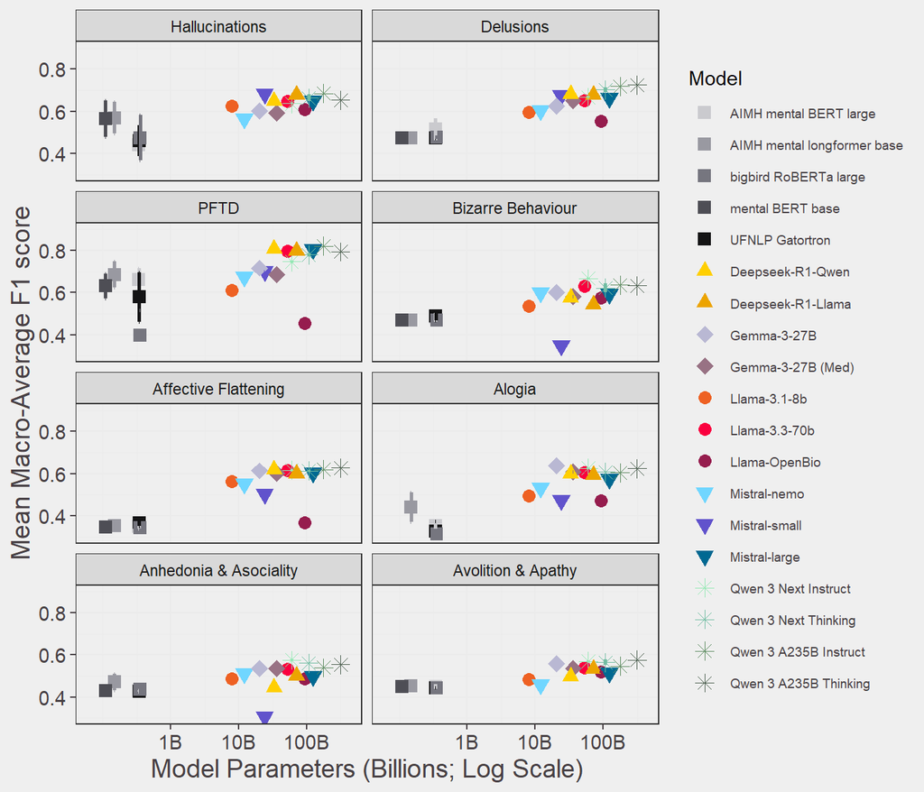

Supplementary Figure 2. Comparison of Mean Macro-Average F1 Score across different symptoms and models in a zero-shot setting. Model size, indexed by number of parameters, is represented on the log scale on the x-axis. Error bars represent standard deviation around the mean.

```r
#### llm results ####
llm_plot_all <- all_symp_zs |>
  dplyr::select(c(
    "Symptom",
    "Macro-Average",
    "Macro-Average.sd",
    "Model",
    "Family",
    "Parameters"
  )) |>
  filter(Symptom != "Positive" & Symptom != "Negative")

llm_plot_all$Symptom <- factor(
  llm_plot_all$Symptom,
  levels = c(
    "Hallucinations",
    "Delusions",
    "PFTD",
    "Bizarre Behaviour",
    "Affective Flattening",
    "Alogia",
    "Anhedonia & Asociality",
    "Avolition & Apathy"
  )
)

#### plm results ####
plm_plot_all <- plms_metrics |>
  dplyr::select(c(
    "Symptom",
    "Macro-Average",
    "Macro-Average.sd",
    "Model",
    "Family",
    "Parameters"
  )) |>
  filter(Symptom != "Positive" & Symptom != "Negative")


plm_plot_all$Symptom <- factor(
  plm_plot_all$Symptom,
  levels = c(
    "Hallucinations",
    "Delusions",
    "PFTD",
    "Bizarre Behaviour",
    "Affective Flattening",
    "Alogia",
    "Anhedonia & Asociality",
    "Avolition & Apathy"
  )
)

#### combine ####
plot_all <- rbind(llm_plot_all, plm_plot_all)

plot_all$Parameters <- as.numeric(plot_all$Parameters)

rownames(plot_all) <- NULL

plot_all$F1 <- as.numeric(plot_all$`Macro-Average`)
plot_all$SD <- as.numeric(plot_all$`Macro-Average.sd`)

plot_all$Model[
  plot_all$Model == "AIMH_mental-bert-large-uncased"
] <- "AIMH mental BERT large"
plot_all$Model[plot_all$Model == "UFNLP_gatortron-base"] <- "UFNLP Gatortron"
plot_all$Model[
  plot_all$Model == "mental_mental-bert-base-uncased"
] <- "mental BERT base"
plot_all$Model[
  plot_all$Model == "AIMH_mental-longformer-base-4096"
] <- "AIMH mental longformer base"
plot_all$Model[
  plot_all$Model == "google_bigbird-roberta-large"
] <- "bigbird RoBERTa large"


plot_all$Model <- factor(
  plot_all$Model,
  levels = c(
    "AIMH mental BERT large",
    "AIMH mental longformer base",
    "bigbird RoBERTa large",
    "mental BERT base",
    "UFNLP Gatortron",
    "Deepseek-R1-Qwen",
    "Deepseek-R1-Llama",
    "Gemma-3-27B",
    "Gemma-3-27B (Med)",
    "Llama-3.1-8b",
    "Llama-3.3-70b",
    "Llama-OpenBio",
    "Mistral-nemo",
    "Mistral-small",
    "Mistral-large",
    "Qwen 3 Next Instruct",
    "Qwen 3 Next Thinking",
    "Qwen 3 A235B Instruct",
    "Qwen 3 A235B Thinking"
  )
)

mod_shapes <- c(15, 17, 18, 19, 13, 8)
pal <- c(
  "#CACACE", # bert-like 1
  "#9999A1", # bert-like 2
  "#76767F", # bert-like 3
  "#4E4E55", # bert-like 4
  "#141415", # bert-like 5
  "#FFCF00", # deepseek 2
  "#ECA400", # deepseek 1
  "#B9B8D3", # gemma 1
  "#987284", # gemma 2
  "#EE6123", # llama 1
  "#FA003F", # llama 2
  "#961D4E", # llama 3
  "#70D6FF", # mistral 1
  "#6153CC", # mistral 2
  "#006992", # mistral 3
  "#94E8B4", # qwen 1
  "#72BDA3", # qwen 2
  "#5E8C61", # qwen 3
  "#4E6151" # qwen 4
)

shp <- c(
  15, # bert-like 1
  15, # bert-like 2
  15, # bert-like 3
  15, # bert-like 4
  15, # bert-like 5
  17, # deepseek 1
  17, # deepseek 2
  23, # gemma 1
  23, # gemma 2
  16, # llama 1
  16, # llama 2
  16, # llama 3
  25, # mistral 1
  25, # mistral 2
  25, # mistral 3
  8, # qwen 1
  8, # qwen 2
  8, # qwen 3
  8 # qwen 4
)
#### create plot ####
zs_full <- ggplot(plot_all, aes(x = Parameters)) +
  geom_point(
    aes(y = F1, shape = Model, color = Model, fill = Model),
    size = 3,
    position = position_dodge(width = 0.5)
  ) +
  geom_errorbar(
    aes(
      ymin = (F1 - SD),
      ymax = (F1 + SD),
      color = Model,
      group = Model
    ),
    linewidth = 1,
    position = position_dodge(width = 0.5),
    size = 0.5,
    show.legend = FALSE
  ) +
  scale_fill_manual(values = pal, name = "Model") +
  scale_colour_manual(values = pal, name = "Model") +
  scale_shape_manual(values = shp, name = "Model") +
  scale_y_continuous(
    name = "Mean Macro-Average F1 score",
    limits = c(0.3, 0.9)
  ) +
  scale_x_log10(
    breaks = c(1e5, 1e6, 1e9, 1e10, 1e11, 1e12),
    labels = c("0.0001", "0.001", "1B", "10B", "100B", "1000B")
  ) +
  xlab("Model Parameters (Billions; Log Scale)") +
  legend_merge(colour, fill, shape) +
  theme_bw() +
  theme(
    axis.title = element_text(colour = "#474044", size = 14),
    axis.text.x = element_text(colour = "#474044", size = 11),
    axis.text.y = element_text(colour = "#474044", size = 11, hjust = 0.5),
    axis.ticks = element_line(colour = "#474044"),
    plot.title = element_text(colour = "#474044"),
    panel.background = element_rect(fill = "#EFEFEF", colour = "#EFEFEF"), # EFEFEF
    plot.background = element_rect(fill = "#EFEFEF", colour = "#EFEFEF"),
    legend.text = element_text(colour = "#474044", size = 7),
    legend.background = element_rect(fill = "#EFEFEF", colour = "#EFEFEF"),
    legend.key = element_rect(fill = "#EFEFEF", colour = "#EFEFEF")
  ) +
  facet_wrap(~Symptom, ncol = 2)


zs_full
```

#### Supplementary Figure 3

##### Relationship between log(OR) for associations using LLM-predicted vs gold-standard phenotypes

```r
c1 <- sdf_plot_p_llm %>% dplyr::select(c("Variable", "symp", "OR", "bf"))
c1$beta <- log(c1$OR)
c1$class <- "LLM-Predicted"
c1$dim <- "Positive"

c2 <- sdf_plot_n_llm %>% dplyr::select(c("Variable", "symp", "OR",  "bf"))
c2$beta <- log(c2$OR)
c2$class <- "LLM-Predicted"
c2$dim <- "Negative"

c_llm <- rbind(c1,c2)

c3 <- sdf_plot_p %>% dplyr::select(c("Variable", "symp", "OR",  "bf"))
c3$beta <- log(c3$OR)
c3$class <- "Gold-Standard"
c3$dim <- "Positive"


c4 <- sdf_plot_n %>% dplyr::select(c("Variable", "symp", "OR",  "bf"))
c4$beta <- log(c4$OR)
c4$class <- "Gold-Standard"
c4$dim <- "Negative"

c_gs <- rbind(c3,c4)

corrs <- full_join(c_llm, c_gs, by = c("Variable", "symp", "dim"))

corrs$dir <- ifelse(corrs$beta.x * corrs$beta.y > 0, "same", "different")

corrs$sig <- "ignore"
#corrs$sig[corrs$bf.x < 0.05 | corrs$bf.y < 0.05] <- "either"
corrs$sig[corrs$bf.y < 0.05] <- "gs" # "Gold-Standard ONLY (FDR < 0.05)"
corrs$sig[corrs$bf.x < 0.05 & corrs$bf.y < 0.05] <- "both" # "Both (FDR < 0.05)"
# corrs$sig[corrs$bf.x >= 0.05 & corrs$bf.y >= 0.05] <- "Neither (FDR > 0.05)"

cor.res <- cor.test(corrs$beta.x, corrs$beta.y, method = "pearson")

agreed_dir <- nrow(filter(corrs, dir == "same"))/nrow(corrs)*100

res_df <- data.frame(Symptom = NA ,
                     r = NA,
                     p = NA)

symp <- unique(corrs$symp)
for (i in 1:length(symp)){
  s <- symp[i]
  df <- filter(corrs, symp == s)
  r <- cor.test(df$beta.x, df$beta.y, method = "pearson")
  res <- c(s, r$estimate, r$p.value)
  res_df <- rbind(res_df, res)
}

res_df <- drop_na(res_df)

facets <- c("AOO", "GAS_worst_in_psychotic_episode", "Depots1",  "OPCRIT_90_Course_of_disorder" , "FINAL_cloz_ever1")

corrs_f <- corrs %>% filter(Variable %in% facets)

names(corrs_f)[names(corrs_f) == 'beta.x'] <- 'beta.llm'
names(corrs_f)[names(corrs_f) == 'beta.y'] <- 'beta.gs'

p <- filter(corrs_f, dim == "Positive")
n <- filter(corrs_f, dim == "Negative")

#cor.test(y = p$beta.llm, x = p$beta.gs, method = "pearson")
#cor.test(y = n$beta.llm, x = n$beta.gs, method = "pearson")

# y = llm, x = gs

n1 <- lm(beta.llm ~ beta.gs, data = n)
p1 <- lm(beta.llm ~ beta.gs, data = p)

p.i <- p1$coefficients[[1]]
p.s <- p1$coefficients[[2]]
n.i <- n1$coefficients[[1]]
n.s <- n1$coefficients[[2]]
```

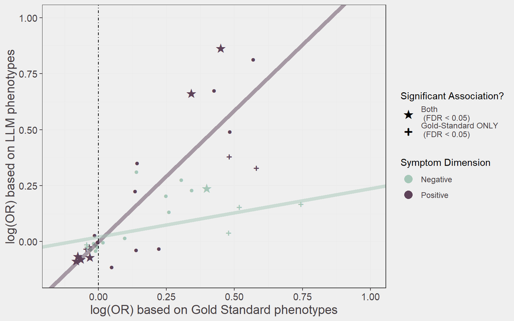

```r
shp2 <- c("\u2605", "\u2795", "\u25cf")


corrs$symp <- factor(
  corrs$symp,
  levels = c(
    "Hallucinations",
    "Delusions",
    "PFTD",
    "Bizarre Behaviour",
    "Affective Flattening",
    "Alogia",
    "Anhedonia & Asociality",
    "Avolition & Apathy"
  )
)

#### create plot ####
overall_cor_plot <- ggplot(corrs_f, aes(x = beta.gs, y = beta.llm)) +
  geom_point(aes(color = dim, fill = dim, shape = sig, size = sig)) +
  geom_abline(intercept = p.i, slope = p.s, colour = "#5E4359", linewidth = 2, alpha = 0.5) +
  geom_abline(intercept = n.i, slope = n.s, colour = "#A6C7B8", linewidth = 2, alpha = 0.5) +
  scale_fill_manual(values = c("#A6C7B8", "#5E4359"), name = "Symptom Dimension") +
  scale_colour_manual(values = c("#A6C7B8", "#5E4359"), name = "Symptom Dimension") +
  scale_shape_manual(values = c(ignore = "\u25cf", both = "\u2605",  gs = "\u2795"),
                     breaks = c('both', 'gs'), labels = c("Both \n (FDR < 0.05)", "Gold-Standard ONLY \n (FDR < 0.05)"), name = "Significant Association?") +
  scale_size_manual(values = c(6, 2.5, 3), guide = "none") +
  ylab("log(OR) based on LLM phenotypes") +
  xlab("log(OR) based on Gold Standard phenotypes") +
  xlim(-0.15, 1) +
  ylim(-0.15, 1) +
  geom_vline(xintercept = 0, linetype = "dotdash") +
  guides(shape = guide_legend(override.aes = list(size = c(6,4)))) +
  guides(fill = guide_legend(override.aes = list(size = c(4,4)))) +
  theme_bw() +
  theme(
    axis.title = element_text(colour = "#474044", size = 14),
    axis.text.x = element_text(colour = "#474044", size = 11),
    axis.text.y = element_text(colour = "#474044", size = 11, hjust = 0.5),
    axis.ticks = element_line(colour = "#474044"),
    plot.title = element_text(colour = "#474044"),
    panel.background = element_rect(fill = "#EFEFEF", colour = "#EFEFEF"), # EFEFEF
    plot.background = element_rect(fill = "#EFEFEF", colour = "#EFEFEF"),
    legend.text = element_text(colour = "#474044", size = 9),
    legend.background = element_rect(fill = "#EFEFEF", colour = "#EFEFEF"),
    legend.key = element_rect(fill = "#EFEFEF", colour = "#EFEFEF")
  )


overall_cor_plot
```

## **Supplementary Tables**

### Supplementary Tables

#### Supplementary Table 1

###### ST1. Symptom Definitions for LLM Prompts

```r
st1 <- readxl::read_xlsx(path = "ZWriteup/Tables/Supplementary.xlsx", sheet = "ST1")

kbl(
  st1,
  escape = FALSE, format = "markdown",
  col.names = c(
    "Symptom",
    "Prompt Definition"),
  caption = "Supplementary Table 1. Symptom definitions used in zero-shot and few-shot prompts for LLMs."
) |>
  kable_paper()
```

Supplementary Table 1. Symptom definitions used in zero-shot and few-shot prompts for LLMs.

| Symptom | Prompt Definition |
| --- | --- |
| Hallucinations | HALLUCINATIONS refer to perceptual experiences occurring without external stimuli. Ensure that ONLY false perceptions are rated as hallucinations, not false thoughts or beliefs. INCLUDE the following … |
| Delusions | DELUSIONS are fixed, false beliefs maintained despite contradictory evidence. These beliefs should be firmly held, fixed, and complex. INCLUDE the following when documented in clinical notes: - Persec… |
| PFTD | POSITIVE FORMAL THOUGHT DISORDER refers to disorganisation in the form (not content) of thinking, as manifested in speech and documented by clinical observations or direct quotes. For a rating of posi… |
| Bizarre Behaviour | BIZARRE BEHAVIOUR refers to clearly unusual, bizarre or odd behaviour. INCLUDE the following when documented in clinical notes: - Unusual appearance/dress: Bizarre clothing choices, inappropriate dres… |
| Affective Flattening | AFFECTIVE FLATTENING (also termed blunted affect or flat affect) refers to a reduction in the range and intensity of emotional expression. Affective flattening relates to reduced emotional expression … |
| Alogia | ALOGIA refers to a reduction in the quantity or content of speech. INCLUDE the following when documented in clinical notes: - Poverty of speech: Reduced amount of spontaneous speech, brief/unelaborate… |
| Anhedonia & Asociality | ANHEDONIA AND ASOCIALITY refer to reduced ability to experience pleasure and reduced social drive. This is seen as a lack of interest in relationships. INCLUDE the following when documented in clinica… |
| Avolition & Apathy | AVOLITION AND APATHY refers to reduced motivation and drive to initiate and persist in goal-directed activities. INCLUDE the following when documented in clinical notes: - Physical anergia: Lack of en… |

#### Supplementary Table 2

```r
st2 <- readxl::read_xlsx(path = "ZWriteup/Tables/Supplementary.xlsx", sheet = "ST2")

st2 <- st2[-4]

kbl(
  st2,
  escape = FALSE, format = "markdown",
  col.names = c(
    "Type",
    "Zero-Shot",
    "Few-Shot"),
  caption = "Supplementary Table 2. Prompts used for binary (i.e., zero-shot, few-shot) analyses. {symp_name} reflects one of the eight symptoms outlined; {definition} for each symptom can be found in Supplementary Table 1 and is derived from the SAPS and SANS ratings guides used during CardiffCOGS data collection (Andreasen 1984; Andreasen 1989). {note} reflects a clinical summary from an individual in the CardiffCOGS sample."
) |>
  kable_paper()
```

Supplementary Table 2. Prompts used for binary (i.e., zero-shot, few-shot) analyses. {symp_name} reflects one of the eight symptoms outlined; {definition} for each symptom can be found in Supplementary Table 1 and is derived from the SAPS and SANS ratings guides used during CardiffCOGS data collection (Andreasen 1984; Andreasen 1989). {note} reflects a clinical summary from an individual in the CardiffCOGS sample.

| Type | Zero-Shot | Few-Shot |
| --- | --- | --- |
| System Prompt | You are a world-leading psychiatrist with expertise in schizophrenia and symptoms of psychosis. Use the patient note to answer the question. Double check your answer before responding. Respond briefly… | You are a world-leading psychiatrist with expertise in schizophrenia and symptoms of psychosis. Use the patient note to answer the question. Double check your answer before responding. Respond briefly… |
| User Prompt | The following is a psychiatric patient note for a symptom classification task. Please scan the text for keywords related to {symp_name} and identify any descriptions matching the definition. {definiti… | The following is a psychiatric patient note for a symptom classification task. Please scan the text for keywords related to {symp_name} and identify any descriptions matching the definition. {definiti… |

#### Supplementary Table 3

###### ST3. Definitions of Evaluation Metrics

```r
st3 <- readxl::read_xlsx(path = "ZWriteup/Tables/Supplementary.xlsx", sheet = "ST3")

kbl(
  st3,
  escape = FALSE, format = "markdown",
  col.names = c(
    "Metric",
    "Equation",
    "Definition"),
  caption = "Supplementary Table 3. Definitions of evaluation metrics used to assess LLM performance. Table adapted from Quinn et al. (2024). TP = True Positives; TN = True Negatives; FP = False Positives; FN = False Negatives."
) |>
  kable_paper()
```

Supplementary Table 3. Definitions of evaluation metrics used to assess LLM performance. Table adapted from Quinn et al. (2024). TP = True Positives; TN = True Negatives; FP = False Positives; FN = False Negatives.

| Metric | Equation | Definition |
| --- | --- | --- |
| Precision | TP/(TP+FP) | The ratio of true positives to the total number of model-predicted positives. |
| Sensitivity (“Recall”) | TP/(TP+FN) | The ratio of true positives to the total number of all positives. This may also be called “Recall” or “True Positive Rate”. |
| Specificity | TN/(TN+FP) | Ratio of true negatives to the total number of all negatives. |
| F1 | (2×TP)/(2 × TP+FP+FN) | Harmonic mean of precision and recall. |
| Accuracy | (TP+TN)/(TP+TN+FP+ FN) | Proportion of correctly predicted examples. |
| Balanced Accuracy (BAC) | (Sensitivity+Specificity)/2 | A measure of accuracy that is more robust to class imbalance. |
| Macro-Average F1 | (∑F1i)/n | Average F1 across all classes (i.e., for binary predictions the average of F1present and F1absent). |
| Matthew’s Correlation Coefficient (MCC) | (TP ×TN-FP×FN)/(√(TP + FP) × (TP + FN) × (TN + FP) × (TN + FN)) | A summary measure that accounts for all parts of the confusion matrix. MCC of 1 indicates perfect agreement between predictions and gold standard. MCC = -1 indicates absolute disagreement. MCC = 0 ref… |

#### Supplementary Tables 4 - 12 PLM Results

##### Supplementary Table 4

###### ST4. Overall PLM Results

```r
colnames(res_overall) <- c("Model", "Precision", "Recall/Sensitivity", "Specificity", "F1 (present)", "Macro-Average","Accuracy", "BAC", "MCC")

res_overall |>
  DT::datatable(
    caption = "Supplementary Table 4. Comparing Mean Metrics for PLMs",
    rownames = FALSE,
    options = list(lengthChange = FALSE, dom = "t", pageLength = 10000)) |>
  formatRound(c(
      "Accuracy",
      "BAC",
      "MCC",
      "F1 (present)",
      "Precision",
      "Recall/Sensitivity",
      "Specificity",
      "Macro-Average"
    ),
    3
  )
```

| Model | Precision | Recall/Sensitivity | Specificity | F1 (present) | Macro-Average | Accuracy | BAC | MCC |
| --- | --- | --- | --- | --- | --- | --- | --- | --- |
| AIMH_mental-bert-large-uncased-binary | 0.6894 | 0.9650666666666666 | 0.09576666666666667 | 0.7945 | 0.4601666666666667 | 0.7055666666666667 | 0.5304333333333333 | 0.08376666666666667 |
| AIMH_mental-longformer-base-4096-binary | 0.7022666666666667 | 0.9345 | 0.1508333333333333 | 0.7933 | 0.4890333333333333 | 0.7167666666666667 | 0.5426666666666666 | 0.1032 |
| UFNLP_gatortron-base-binary | 0.6837666666666666 | 0.9601 | 0.08063333333333333 | 0.7869666666666667 | 0.4450666666666667 | 0.6954333333333333 | 0.5204 | 0.05056666666666667 |
| google_bigbird-roberta-large-binary | 0.6725 | 0.9879666666666667 | 0.03523333333333333 | 0.7853666666666667 | 0.4194 | 0.6778333333333333 | 0.5115666666666667 | 0.03783333333333333 |
| mental_mental-bert-base-uncased-binary | 0.6898333333333333 | 0.9628 | 0.09926666666666667 | 0.7925333333333333 | 0.4577333333333333 | 0.7042 | 0.5310333333333334 | 0.07926666666666667 |

##### Supplementary Table 5

###### ST5. Hallucinations PLM Results

```r
plms_metrics |>
  filter(Symptom == "Hallucinations") |>
  dplyr::select(-c("Macro-Average.sd", "Family", "Parameters", "Symptom")) |>
  DT::datatable(
    caption = "Supplementary Table 5. Full PLM results for detecting presence or absence of Hallucinations",
    rownames = FALSE,
    options = list(lengthChange = FALSE, dom = "t", pageLength = 10000)) |>
  formatRound(c(
      "Precision",
      "Recall/Sensitivity",
      "Specificity",
      "F1 (present)",
      "Macro-Average",
      "Accuracy",
      "BAC",
      "MCC"
    ),
    3
  )
```

| Model | Precision | Recall/Sensitivity | Specificity | F1 (present) | Macro-Average | Accuracy | BAC | MCC |
| --- | --- | --- | --- | --- | --- | --- | --- | --- |
| AIMH_mental-bert-large-uncased | 0.7007666666666666 | 0.9863666666666667 | 0.03286666666666667 | 0.8193666666666667 | 0.4396 | 0.6970666666666667 | 0.5096333333333334 | 0.0533 |
| AIMH_mental-longformer-base-4096 | 0.7392000000000001 | 0.9188666666666667 | 0.2472333333333333 | 0.8174333333333333 | 0.5686666666666667 | 0.7151 | 0.5830666666666667 | 0.2345333333333333 |
| UFNLP_gatortron-base | 0.7045 | 0.9679666666666666 | 0.06573333333333334 | 0.8152 | 0.4591 | 0.6942 | 0.5168333333333334 | 0.0487 |
| google_bigbird-roberta-large | 0.7127666666666667 | 0.97 | 0.09546666666666667 | 0.8206 | 0.4749666666666667 | 0.7046666666666667 | 0.5327333333333333 | 0.1017666666666667 |
| mental_mental-bert-base-uncased | 0.7358 | 0.9529666666666666 | 0.2096666666666667 | 0.8298 | 0.5655666666666667 | 0.7274333333333333 | 0.5813666666666667 | 0.2435333333333333 |

##### Supplementary Table 6

###### ST6. Delusions PLM Results

```r
plms_metrics |>
  filter(Symptom == "Delusions") |>
  dplyr::select(-c("Macro-Average.sd", "Family", "Parameters", "Symptom")) |>
  DT::datatable(
    caption = "Supplementary Table 6. Full PLM results for detecting presence or absence of Delusions",
    rownames = FALSE,
    options = list(lengthChange = FALSE, dom = "t", pageLength = 10000)) |>
  formatRound(c(
      "Precision",
      "Recall/Sensitivity",
      "Specificity",
      "F1 (present)",
      "Macro-Average",
      "Accuracy",
      "BAC",
      "MCC"
    ),
    3
  )
```

| Model | Precision | Recall/Sensitivity | Specificity | F1 (present) | Macro-Average | Accuracy | BAC | MCC |
| --- | --- | --- | --- | --- | --- | --- | --- | --- |
| AIMH_mental-bert-large-uncased | 0.9006333333333333 | 0.9952333333333333 | 0.05023333333333334 | 0.9455666666666667 | 0.5151666666666667 | 0.8972333333333333 | 0.5227333333333334 | 0.1092666666666667 |
| AIMH_mental-longformer-base-4096 | 0.8963 | 1 | 0 | 0.9453 | 0.4727 | 0.8963 | 0.5 | 0 |
| UFNLP_gatortron-base | 0.8963 | 1 | 0 | 0.9453 | 0.4727 | 0.8963 | 0.5 | 0 |
| google_bigbird-roberta-large | 0.8966666666666666 | 0.9994666666666666 | 0.004566666666666667 | 0.9452666666666667 | 0.4771333333333334 | 0.8963 | 0.5020333333333333 | 0.02313333333333334 |
| mental_mental-bert-base-uncased | 0.8963 | 1 | 0 | 0.9453 | 0.4727 | 0.8963 | 0.5 | 0 |

##### Supplementary Table 7

###### ST7. PFTD PLM Results

```r
plms_metrics |>
  filter(Symptom == "PFTD") |>
  dplyr::select(-c("Macro-Average.sd", "Family", "Parameters", "Symptom")) |>
  DT::datatable(
    caption = "Supplementary Table 7. Full PLM results for detecting presence or absence of PFTD",
    rownames = FALSE,
    options = list(lengthChange = FALSE, dom = "t", pageLength = 10000)) |>
  formatRound(c(
      "Precision",
      "Recall/Sensitivity",
      "Specificity",
      "F1 (present)",
      "Macro-Average",
      "Accuracy",
      "BAC",
      "MCC"
    ),
    3
  )
```

| Model | Precision | Recall/Sensitivity | Specificity | F1 (present) | Macro-Average | Accuracy | BAC | MCC |
| --- | --- | --- | --- | --- | --- | --- | --- | --- |
| AIMH_mental-bert-large-uncased | 0.5373 | 0.8036333333333333 | 0.5846666666666667 | 0.6401333333333333 | 0.6617333333333333 | 0.6652333333333333 | 0.6941 | 0.3818666666666667 |
| AIMH_mental-longformer-base-4096 | 0.5787 | 0.6977 | 0.6945 | 0.6305 | 0.6853333333333333 | 0.6956666666666667 | 0.6960666666666667 | 0.3833333333333334 |
| UFNLP_gatortron-base | 0.4933333333333333 | 0.7648666666666667 | 0.4966 | 0.5838333333333333 | 0.5784333333333334 | 0.5953333333333333 | 0.6307333333333334 | 0.2776666666666667 |
| google_bigbird-roberta-large | 0.3963333333333333 | 0.9431666666666667 | 0.1557333333333333 | 0.5568333333333333 | 0.3984666666666667 | 0.4455333333333333 | 0.5494333333333333 | 0.1267333333333333 |
| mental_mental-bert-base-uncased | 0.5146666666666667 | 0.7519333333333333 | 0.5718666666666666 | 0.6054 | 0.6312 | 0.6381333333333333 | 0.6618999999999999 | 0.3212 |

##### Supplementary Table 8

###### ST8. Bizarre Behaviour PLM Results

```r
plms_metrics |>
  filter(Symptom == "Bizarre Behaviour") |>
  dplyr::select(-c("Macro-Average.sd", "Family", "Parameters", "Symptom")) |>
  DT::datatable(
    caption = "Supplementary Table 8. Full PLM results for detecting presence or absence of Bizarre Behaviour",
    rownames = FALSE,
    options = list(lengthChange = FALSE, dom = "t", pageLength = 10000)) |>
  formatRound(c(
      "Precision",
      "Recall/Sensitivity",
      "Specificity",
      "F1 (present)",
      "Macro-Average",
      "Accuracy",
      "BAC",
      "MCC"
    ),
    3
  )
```

| Model | Precision | Recall/Sensitivity | Specificity | F1 (present) | Macro-Average | Accuracy | BAC | MCC |
| --- | --- | --- | --- | --- | --- | --- | --- | --- |
| AIMH_mental-bert-large-uncased | 0.8876 | 0.9994666666666666 | 0.0125 | 0.9402333333333334 | 0.4820333333333333 | 0.8873333333333333 | 0.5059666666666667 | 0.05053333333333334 |
| AIMH_mental-longformer-base-4096 | 0.8864 | 1 | 0 | 0.9398 | 0.4699 | 0.8864 | 0.5 | 0 |
| UFNLP_gatortron-base | 0.888 | 0.9952 | 0.02083333333333334 | 0.9385666666666667 | 0.4877333333333334 | 0.8845 | 0.508 | 0.06306666666666667 |
| google_bigbird-roberta-large | 0.8864 | 1 | 0 | 0.9398 | 0.4699 | 0.8864 | 0.5 | 0 |
| mental_mental-bert-base-uncased | 0.8864 | 1 | 0 | 0.9398 | 0.4699 | 0.8864 | 0.5 | 0 |

##### Supplementary Table 9

###### ST9. Affective Flattening PLM Results

```r
plms_metrics |>
  filter(Symptom == "Affective Flattening") |>
  dplyr::select(-c("Macro-Average.sd", "Family", "Parameters", "Symptom")) |>
  DT::datatable(
    caption = "Supplementary Table 9. Full PLM results for detecting presence or absence of Affective Flattening",
    rownames = FALSE,
    options = list(lengthChange = FALSE, dom = "t", pageLength = 10000)) |>
  formatRound(c(
      "Precision",
      "Recall/Sensitivity",
      "Specificity",
      "F1 (present)",
      "Macro-Average",
      "Accuracy",
      "BAC",
      "MCC"
    ),
    3
  )
```

| Model | Precision | Recall/Sensitivity | Specificity | F1 (present) | Macro-Average | Accuracy | BAC | MCC |
| --- | --- | --- | --- | --- | --- | --- | --- | --- |
| AIMH_mental-bert-large-uncased | 0.5215666666666666 | 0.9918 | 0.008933333333333335 | 0.6836 | 0.3503666666666667 | 0.5214 | 0.5003666666666666 | 0.002933333333333333 |
| AIMH_mental-longformer-base-4096 | 0.5225333333333333 | 0.9945333333333334 | 0.009933333333333334 | 0.6850666666666667 | 0.352 | 0.5233 | 0.5022333333333333 | 0.0149 |
| UFNLP_gatortron-base | 0.5215666666666666 | 0.9699333333333333 | 0.03076666666666667 | 0.6783 | 0.3676666666666666 | 0.5204 | 0.5003333333333333 | 9.99999999999999e-05 |
| google_bigbird-roberta-large | 0.5214 | 1 | 0 | 0.6854 | 0.3427 | 0.5214 | 0.5 | 0 |
| mental_mental-bert-base-uncased | 0.5218666666666667 | 1 | 0.002 | 0.6858000000000001 | 0.3449 | 0.5223333333333333 | 0.501 | 0.02626666666666666 |

##### Supplementary Table 10

###### ST10. Alogia PLM Results

```r
plms_metrics |>
  filter(Symptom == "Alogia") |>
  dplyr::select(-c("Macro-Average.sd", "Family", "Parameters", "Symptom")) |>
  DT::datatable(
    caption = "Supplementary Table 10. Full PLM results for detecting presence or absence of Alogia",
    rownames = FALSE,
    options = list(lengthChange = FALSE, dom = "t", pageLength = 10000)) |>
  formatRound(c(
      "Precision",
      "Recall/Sensitivity",
      "Specificity",
      "F1 (present)",
      "Macro-Average",
      "Accuracy",
      "BAC",
      "MCC"
    ),
    3
  )
```

| Model | Precision | Recall/Sensitivity | Specificity | F1 (present) | Macro-Average | Accuracy | BAC | MCC |
| --- | --- | --- | --- | --- | --- | --- | --- | --- |
| AIMH_mental-bert-large-uncased | 0.4283666666666667 | 0.9519 | 0.06586666666666667 | 0.5907333333333333 | 0.3543 | 0.4414333333333333 | 0.5088666666666667 | 0.04683333333333333 |
| AIMH_mental-longformer-base-4096 | 0.4494333333333333 | 0.9004666666666666 | 0.1843666666666667 | 0.5988 | 0.4410333333333333 | 0.4879333333333333 | 0.5424 | 0.1125333333333333 |
| UFNLP_gatortron-base | 0.4280333333333333 | 0.9843333333333333 | 0.03126666666666666 | 0.5964333333333334 | 0.3259333333333334 | 0.4352666666666667 | 0.5078 | 0.0295 |
| google_bigbird-roberta-large | 0.4265 | 0.9955333333333334 | 0.0148 | 0.5971333333333334 | 0.3126333333333334 | 0.4305333333333333 | 0.5051666666666667 | 0.02933333333333333 |
| mental_mental-bert-base-uncased | 0.4239 | 1 | 0 | 0.5954 | 0.2977 | 0.4239 | 0.5 | 0 |

##### Supplementary Table 11

###### ST11. Anhedonia & Asociality PLM Results

```r
plms_metrics |>
  filter(Symptom == "Anhedonia & Asociality") |>
  dplyr::select(-c("Macro-Average.sd", "Family", "Parameters", "Symptom")) |>
  DT::datatable(
    caption = "Supplementary Table 11. Full PLM results for detecting presence or absence of Anhedonia & Asociality",
    rownames = FALSE,
    options = list(lengthChange = FALSE, dom = "t", pageLength = 10000)) |>
  formatRound(c(
      "Precision",
      "Recall/Sensitivity",
      "Specificity",
      "F1 (present)",
      "Macro-Average",
      "Accuracy",
      "BAC",
      "MCC"
    ),
    3
  )
```

| Model | Precision | Recall/Sensitivity | Specificity | F1 (present) | Macro-Average | Accuracy | BAC | MCC |
| --- | --- | --- | --- | --- | --- | --- | --- | --- |
| AIMH_mental-bert-large-uncased | 0.7450333333333333 | 1 | 0.001866666666666667 | 0.8538333333333333 | 0.4287666666666667 | 0.7451666666666666 | 0.5009333333333333 | 0.0215 |
| AIMH_mental-longformer-base-4096 | 0.7503666666666666 | 0.9668 | 0.06143333333333333 | 0.8446666666666667 | 0.4715333333333334 | 0.7356333333333334 | 0.5141 | 0.05429999999999999 |
| UFNLP_gatortron-base | 0.7444333333333333 | 0.9987333333333334 | 0 | 0.853 | 0.4265333333333333 | 0.7437 | 0.4993333333333334 | -0.01473333333333333 |
| google_bigbird-roberta-large | 0.7459666666666667 | 0.9955333333333334 | 0.01116666666666667 | 0.8528 | 0.4368333333333334 | 0.7442 | 0.5033666666666666 | 0.02166666666666667 |
| mental_mental-bert-base-uncased | 0.7450333333333333 | 0.9981 | 0.003733333333333333 | 0.8531333333333333 | 0.4302 | 0.7442 | 0.5009 | 0.009366666666666667 |

##### Supplementary Table 12

###### ST12. Avolition & Apathy PLM Results

```r
plms_metrics |>
  filter(Symptom == "Avolition & Apathy") |>
  dplyr::select(-c("Macro-Average.sd", "Family", "Parameters", "Symptom")) |>
  DT::datatable(
    caption = "Supplementary Table 12. Full PLM results for detecting presence or absence of Avolition & Apathy",
    rownames = FALSE,
    options = list(lengthChange = FALSE, dom = "t", pageLength = 10000)) |>
  formatRound(c(
      "Precision",
      "Recall/Sensitivity",
      "Specificity",
      "F1 (present)",
      "Macro-Average",
      "Accuracy",
      "BAC",
      "MCC"
    ),
    3
  )
```

| Model | Precision | Recall/Sensitivity | Specificity | F1 (present) | Macro-Average | Accuracy | BAC | MCC |
| --- | --- | --- | --- | --- | --- | --- | --- | --- |
| AIMH_mental-bert-large-uncased | 0.7942666666666667 | 0.9922333333333333 | 0.0092 | 0.8822666666666666 | 0.4493666666666666 | 0.7897333333333334 | 0.5007333333333334 | 0.0038 |
| AIMH_mental-longformer-base-4096 | 0.7951333333333334 | 0.9976 | 0.0092 | 0.8849666666666667 | 0.4512 | 0.794 | 0.5034 | 0.026 |
| UFNLP_gatortron-base | 0.794 | 1 | 0 | 0.8852 | 0.4426 | 0.794 | 0.5 | 0 |
| google_bigbird-roberta-large | 0.794 | 1 | 0 | 0.8852 | 0.4426 | 0.794 | 0.5 | 0 |
| mental_mental-bert-base-uncased | 0.7950333333333334 | 0.9994 | 0.0069 | 0.8855999999999999 | 0.4495 | 0.7949666666666667 | 0.5031666666666667 | 0.0339 |

#### Supplementary Tables 13 - 21 LLM (Zero-Shot) Results

##### Supplementary Table 13

###### ST13. Overall LLM (Zero-Shot) Results

```r
all_symp_zs_all <- all_symp_zs |>
  dplyr::select(c("Model", "Symptom","Precision", "Recall/Sensitivity", "Specificity", "F1 (present)", "Macro-Average","Accuracy", "BAC", "MCC")) |>
  filter(Symptom != "Positive" & Symptom != "Negative") |>
  group_by(Model) |>
  summarise_at(
    vars(c(
      "Precision",
      "Recall/Sensitivity",
      "Specificity",
      "F1 (present)",
      "Macro-Average",
      "Accuracy",
      "BAC",
      "MCC"
    )),
    list(mean = mean)
  )

colnames(all_symp_zs_all) <- c("Model", "Precision", "Recall/Sensitivity", "Specificity", "F1 (present)", "Macro-Average","Accuracy", "BAC", "MCC")

all_symp_zs_all |>
  DT::datatable(
    caption = "Supplementary Table 13. Comparing Mean Metrics for LLMs (Zero-Shot)",
    rownames = FALSE,
    options = list(lengthChange = FALSE, dom = "t", pageLength = 10000)) |>
  formatRound(c(
      "Accuracy",
      "BAC",
      "MCC",
      "F1 (present)",
      "Precision",
      "Recall/Sensitivity",
      "Specificity",
      "Macro-Average"
    ),
    3
  )
```

| Model | Precision | Recall/Sensitivity | Specificity | F1 (present) | Macro-Average | Accuracy | BAC | MCC |
| --- | --- | --- | --- | --- | --- | --- | --- | --- |
| Deepseek-R1-Llama | 0.8089459580906365 | 0.6156347704468534 | 0.6978130566667936 | 0.6878480783648192 | 0.615444722959697 | 0.6776539951577144 | 0.6567239135568236 | 0.2995078320758816 |
| Deepseek-R1-Qwen | 0.8075517303951267 | 0.6153687938137478 | 0.6926496209830123 | 0.6803190141752712 | 0.6091185475443065 | 0.6731576482462494 | 0.6540092073983801 | 0.297697639251507 |
| Gemma-3-27B | 0.7646987944289911 | 0.7251877541638303 | 0.5498596825529982 | 0.7302975722723972 | 0.611046445373048 | 0.6928649490287528 | 0.6375237183584143 | 0.2718640293958571 |
| Gemma-3-27B (Med) | 0.7444530916695297 | 0.7358910982518656 | 0.5167533980655505 | 0.727060800203836 | 0.5992932477741229 | 0.6773015051803974 | 0.6263222481587081 | 0.2499373370200089 |
| Llama-3.1-8b | 0.7120910265966568 | 0.665749867521539 | 0.4840700603261273 | 0.6744394133880188 | 0.5488137685723331 | 0.6189196413153925 | 0.5749099639238331 | 0.1395446846847456 |
| Llama-3.3-70b | 0.7778454229549872 | 0.7122415915446317 | 0.5743309735276414 | 0.7343708148549783 | 0.6273253728000459 | 0.7095465900042637 | 0.6432862825361365 | 0.2910353783184583 |
| Llama-OpenBio | 0.6846305605166271 | 0.9524336026595173 | 0.1444129607600448 | 0.7835337397781469 | 0.5041557605327195 | 0.6898747002936738 | 0.548423281709781 | 0.1532237000962945 |
| Mistral-large | 0.7916348768792638 | 0.6463296085725051 | 0.6524250026612979 | 0.6981809045370715 | 0.612990094125645 | 0.6835460155795943 | 0.6493773056169014 | 0.2880955894306625 |
| Mistral-nemo | 0.7256866937675596 | 0.6713751565438301 | 0.5080490612114938 | 0.679562706662112 | 0.5629555221959079 | 0.6480576649330937 | 0.5897121088776619 | 0.1824268868702098 |
| Mistral-small | 0.8560326386769821 | 0.371399012708325 | 0.8580950577417047 | 0.4531009501350576 | 0.4925031691201462 | 0.5577278158985082 | 0.6147470352250148 | 0.2445596837900604 |

[output cut: 4 more lines]

##### Supplementary Table 14

###### ST14. Hallucinations LLM (Zero-Shot) Results

```r
all_symp_zst <- all_symp_zs |>
  dplyr::select(c("Model", "Symptom" , "Precision","Recall/Sensitivity", "Specificity", "F1 (present)", "Macro-Average","Accuracy", "BAC", "MCC"))

all_symp_zst |>
  filter(Symptom == "Hallucinations") |>
  dplyr::select(-c("Symptom")) |>
  DT::datatable(
    caption = "Supplementary Table 14. Full LLM results (Zero-Shot) for detecting presence or absence of Hallucinations",
    rownames = FALSE,
    options = list(lengthChange = FALSE, dom = "t", pageLength = 10000)) |>
  formatRound(c(
      "Precision",
      "Recall/Sensitivity",
      "Specificity",
      "F1 (present)",
      "Macro-Average",
      "Accuracy",
      "BAC",
      "MCC"
    ),
    3
  )
```

| Model | Precision | Recall/Sensitivity | Specificity | F1 (present) | Macro-Average | Accuracy | BAC | MCC |
| --- | --- | --- | --- | --- | --- | --- | --- | --- |
| Llama-3.1-8b | 0.7634249074211809 | 0.8268817204301075 | 0.4108910891089109 | 0.7938166729150335 | 0.6237432175262688 | 0.7006842964060138 | 0.6188864047695092 | 0.2536775405060213 |
| Llama-3.3-70b | 0.7636760074295404 | 0.9516019086571234 | 0.323943661971831 | 0.8473442490358017 | 0.6494087579690956 | 0.7611585944919278 | 0.6377727853144771 | 0.374244657745835 |
| Llama-OpenBio | 0.7463161509814654 | 0.9506579157206773 | 0.2630783118934778 | 0.836183935454951 | 0.6093380401929728 | 0.7410610114540213 | 0.6068681138070775 | 0.3090049334179341 |
| Mistral-nemo | 0.7312703583061889 | 0.9219712525667351 | 0.2216981132075472 | 0.8156221616712079 | 0.5660602390847622 | 0.709585121602289 | 0.5718346828871411 | 0.2020705098402905 |
| Mistral-small | 0.7903525046382189 | 0.8729508196721312 | 0.4694835680751174 | 0.8296007789678675 | 0.6814670561506004 | 0.7503566333808844 | 0.6712171938736242 | 0.3736157651637265 |
| Mistral-large | 0.7653910149750416 | 0.9406952965235174 | 0.3349056603773585 | 0.8440366972477064 | 0.6495824511879558 | 0.7574893009985735 | 0.6378004784504379 | 0.3619643886202068 |
| Gemma-3-27B | 0.744408945686901 | 0.9529652351738241 | 0.2488262910798122 | 0.8358744394618836 | 0.6013282231911494 | 0.7393162393162394 | 0.6008957631268181 | 0.2985748299818367 |
| Gemma-3-27B (Med) | 0.740506329113924 | 0.9669421487603306 | 0.2264150943396226 | 0.8387096774193546 | 0.5932678821879382 | 0.7413793103448276 | 0.5966786215499766 | 0.3079658284948943 |
| Qwen 3 Next Instruct | 0.759228650137741 | 0.9393319700068167 | 0.3161189358372457 | 0.8397318708104813 | 0.6370702364805095 | 0.7502374169040836 | 0.6277254529220312 | 0.3403205103835656 |
| Qwen 3 Next Thinking | 0.7736024007542123 | 0.9175187457396047 | 0.3834115805946792 | 0.8394281544416389 | 0.6633802724649499 | 0.7554605887939222 | 0.650465163167142 | 0.3649005542056569 |

[output cut: 4 more lines]

##### Supplementary Table 15

###### ST15. Delusions LLM (Zero-Shot) Results

```r
all_symp_zst |>
  filter(Symptom == "Delusions") |>
  dplyr::select(-c("Symptom")) |>
  DT::datatable(
    caption = "Supplementary Table 15. Full LLM (Zero-Shot) results for detecting presence or absence of Delusions",
    rownames = FALSE,
    options = list(lengthChange = FALSE, dom = "t", pageLength = 10000)) |>
  formatRound(c(
      "Precision",
      "Recall/Sensitivity",
      "Specificity",
      "F1 (present)",
      "Macro-Average",
      "Accuracy",
      "BAC",
      "MCC"
    ),
    3
  )
```

| Model | Precision | Recall/Sensitivity | Specificity | F1 (present) | Macro-Average | Accuracy | BAC | MCC |
| --- | --- | --- | --- | --- | --- | --- | --- | --- |
| Llama-3.1-8b | 0.9164882437377795 | 0.9159513325198507 | 0.2765700483091788 | 0.9161848407513974 | 0.5968431647466449 | 0.8498246213172256 | 0.5962606904145147 | 0.1942286625487819 |
| Llama-3.3-70b | 0.9222560975609756 | 0.9587955625990491 | 0.3013698630136986 | 0.94017094017094 | 0.6519036519036518 | 0.890625 | 0.6300827128063738 | 0.3146684147993429 |
| Llama-OpenBio | 0.9024385702782083 | 0.9883137911781128 | 0.09859154929577464 | 0.9434260070066461 | 0.5540659446797936 | 0.8940293779058872 | 0.5434526702369438 | 0.1870135305287213 |
| Mistral-nemo | 0.9118086696562033 | 0.9713375796178344 | 0.1917808219178082 | 0.9406322282189669 | 0.6036494474428168 | 0.8901569186875892 | 0.5815592007678213 | 0.2387020566247005 |
| Mistral-small | 0.9584837545126353 | 0.8509615384615384 | 0.676056338028169 | 0.901528013582343 | 0.6771791011307942 | 0.8330935251798561 | 0.7635089382448537 | 0.3969011682977137 |
| Mistral-large | 0.9290220820189274 | 0.9349206349206349 | 0.3835616438356164 | 0.9319620253164558 | 0.6631641112497771 | 0.8776671408250356 | 0.6592411393781257 | 0.3265485821776916 |
| Gemma-3-27B | 0.9176829268292683 | 0.9540412044374009 | 0.2602739726027397 | 0.9355089355089355 | 0.6247792611428975 | 0.8821022727272727 | 0.6071575885200703 | 0.2592128330189514 |
| Gemma-3-27B (Med) | 0.9227202472952086 | 0.9521531100478469 | 0.3150684931506849 | 0.9372056514913657 | 0.6511425082853654 | 0.8857142857142857 | 0.6336108015992659 | 0.3087284770498495 |
| Qwen 3 Next Instruct | 0.9275369195440996 | 0.9466455361859483 | 0.3607305936073059 | 0.9369934383205898 | 0.6664803711895085 | 0.8858901515151515 | 0.653688064896627 | 0.3355933580798584 |
| Qwen 3 Next Thinking | 0.9521517150103863 | 0.8932910723718964 | 0.6118721461187214 | 0.9217770369028724 | 0.7022532094733355 | 0.8641098484848485 | 0.7525816092453089 | 0.4209767362307997 |

[output cut: 4 more lines]

##### Supplementary Table 16

###### ST16. PFTD LLM (Zero-Shot) Results

```r
all_symp_zst |>
  filter(Symptom == "PFTD") |>
  dplyr::select(-c("Symptom")) |>
  DT::datatable(
    caption = "Supplementary Table 16. Full LLM results (Zero-Shot) for detecting presence or absence of PFTD",
    rownames = FALSE,
    options = list(lengthChange = FALSE, dom = "t", pageLength = 10000)) |>
  formatRound(c(
      "Precision",
      "Recall/Sensitivity",
      "Specificity",
      "F1 (present)",
      "Macro-Average",
      "Accuracy",
      "BAC",
      "MCC"
    ),
    3
  )
```

| Model | Precision | Recall/Sensitivity | Specificity | F1 (present) | Macro-Average | Accuracy | BAC | MCC |
| --- | --- | --- | --- | --- | --- | --- | --- | --- |
| Llama-3.1-8b | 0.4803451178451179 | 0.7048401260395681 | 0.5631911532385466 | 0.5712845405273962 | 0.6107370661350203 | 0.6147471553315969 | 0.6340156396390574 | 0.2585847240747307 |
| Llama-3.3-70b | 0.6916528811690102 | 0.8346253229974161 | 0.7832957110609481 | 0.7564409850918377 | 0.7949534523319362 | 0.802187351402758 | 0.808960517029182 | 0.5997731996347263 |
| Llama-OpenBio | 0.4108473895816406 | 0.9671086074714969 | 0.2015151515151515 | 0.576700118607176 | 0.4534579613517885 | 0.4812513775049798 | 0.5843118794933242 | 0.2340531007553068 |
| Mistral-nemo | 0.5427807486631016 | 0.79296875 | 0.6113636363636363 | 0.6444444444444444 | 0.6752405949256343 | 0.6781609195402298 | 0.7021661931818182 | 0.3910399358281805 |
| Mistral-small | 0.7916666666666666 | 0.4470588235294118 | 0.9319727891156463 | 0.5714285714285714 | 0.6996115666810531 | 0.7543103448275862 | 0.6895158063225291 | 0.4508312719479323 |
| Mistral-large | 0.7407407407407407 | 0.7751937984496124 | 0.8416289592760181 | 0.7575757575757576 | 0.8053933833750347 | 0.8171428571428572 | 0.8084113788628153 | 0.6113153014173206 |
| Gemma-3-27B | 0.5757575757575758 | 0.8837209302325582 | 0.6207674943566591 | 0.6972477064220183 | 0.7162709120345385 | 0.717546362339515 | 0.7522442122946087 | 0.4907557641888368 |
| Gemma-3-27B (Med) | 0.5459057071960298 | 0.8627450980392157 | 0.5821917808219178 | 0.668693009118541 | 0.6846212298339958 | 0.6854256854256854 | 0.7224684394305667 | 0.4349647146942394 |
| Qwen 3 Next Instruct | 0.6096766348146256 | 0.8798449612403101 | 0.671933784800602 | 0.7202557030086488 | 0.7458711295650398 | 0.748454588682834 | 0.775889373020456 | 0.5332584022547181 |
| Qwen 3 Next Thinking | 0.6695883281667865 | 0.82687338501292 | 0.7622272385252069 | 0.7399286906143951 | 0.7790745901346212 | 0.7860199714693294 | 0.7945503117690634 | 0.5706336339710769 |

[output cut: 4 more lines]

##### Supplementary Table 17

###### ST17. Bizarre Behaviour LLM (Zero-Shot) Results

```r
all_symp_zst |>
  filter(Symptom == "Bizarre Behaviour") |>
  dplyr::select(-c("Symptom")) |>
  DT::datatable(
    caption = "Supplementary Table 17. Full LLM results (Zero-Shot) for detecting presence or absence of Bizarre Behaviour",
    rownames = FALSE,
    options = list(lengthChange = FALSE, dom = "t", pageLength = 10000)) |>
  formatRound(c(
      "Precision",
      "Recall/Sensitivity",
      "Specificity",
      "F1 (present)",
      "Macro-Average",
      "Accuracy",
      "BAC",
      "MCC"
    ),
    3
  )
```

| Model | Precision | Recall/Sensitivity | Specificity | F1 (present) | Macro-Average | Accuracy | BAC | MCC |
| --- | --- | --- | --- | --- | --- | --- | --- | --- |
| Llama-3.1-8b | 0.9181862387551665 | 0.7089208681319548 | 0.5089489489489489 | 0.8000785018540899 | 0.5349887458765399 | 0.6861415527236335 | 0.608934908540452 | 0.1489550299388643 |
| Llama-3.3-70b | 0.9298655278008214 | 0.8498931623931624 | 0.5 | 0.8880824391600028 | 0.6312496205569953 | 0.8101325757575758 | 0.6749465811965812 | 0.2831391346611865 |
| Llama-OpenBio | 0.8971172453677959 | 0.9788503129330968 | 0.1375 | 0.9362032851589689 | 0.5738708733487152 | 0.8819577191272918 | 0.5581751564665484 | 0.2033636792096576 |
| Mistral-nemo | 0.9237749546279492 | 0.8196457326892109 | 0.475 | 0.8686006825938567 | 0.5995177326012762 | 0.7803138373751783 | 0.6473228663446055 | 0.2284386159818078 |
| Mistral-small | 0.9887005649717514 | 0.2827140549273021 | 0.975 | 0.4396984924623116 | 0.3494173525434482 | 0.3619456366237482 | 0.628857027463651 | 0.1886716022451643 |
| Mistral-large | 0.9642058165548099 | 0.6929260450160771 | 0.8 | 0.8063610851262861 | 0.594225318682546 | 0.7051282051282052 | 0.7464630225080386 | 0.3256852572688069 |
| Gemma-3-27B | 0.9361702127659575 | 0.7756410256410257 | 0.5875 | 0.848378615249781 | 0.600219270171707 | 0.7542613636363636 | 0.6815705128205128 | 0.2609435277262842 |
| Gemma-3-27B (Med) | 0.941544885177453 | 0.72508038585209 | 0.65 | 0.8192552225249772 | 0.5812447729786603 | 0.7165242165242165 | 0.687540192926045 | 0.2560025856288765 |
| Qwen 3 Next Instruct | 0.9310741692960929 | 0.8947649572649573 | 0.4833333333333333 | 0.9125558569709803 | 0.6660458885731433 | 0.8480113636363636 | 0.6890491452991453 | 0.3377641996659795 |
| Qwen 3 Next Thinking | 0.9377739086379847 | 0.8050213675213675 | 0.5833333333333334 | 0.866333412471612 | 0.621102942463569 | 0.7798295454545454 | 0.6941773504273504 | 0.2890000259875544 |

[output cut: 4 more lines]

##### Supplementary Table 18

###### ST18. Affective Flattening LLM (Zero-Shot) Results

```r
all_symp_zst |>
  filter(Symptom == "Affective Flattening") |>
  dplyr::select(-c("Symptom")) |>
  DT::datatable(
    caption = "Supplementary Table 18. Full LLM results (Zero-Shot) for detecting presence or absence of Affective Flattening",
    rownames = FALSE,
    options = list(lengthChange = FALSE, dom = "t", pageLength = 10000)) |>
  formatRound(c(
      "Precision",
      "Recall/Sensitivity",
      "Specificity",
      "F1 (present)",
      "Macro-Average",
      "Accuracy",
      "BAC",
      "MCC"
    ),
    3
  )
```

| Model | Precision | Recall/Sensitivity | Specificity | F1 (present) | Macro-Average | Accuracy | BAC | MCC |
| --- | --- | --- | --- | --- | --- | --- | --- | --- |
| Llama-3.1-8b | 0.5943223443223443 | 0.531694767409763 | 0.5979696252704807 | 0.5612593606967936 | 0.5631117652540855 | 0.5631467333594993 | 0.5648321963401218 | 0.1297030300664234 |
| Llama-3.3-70b | 0.6837522911757005 | 0.4981785063752277 | 0.7490079365079365 | 0.5763952668077573 | 0.6144722223727682 | 0.6182336182336182 | 0.623593221441582 | 0.2544143510344531 |
| Llama-OpenBio | 0.5183724235963042 | 0.9747899159663865 | 0.03000024048288964 | 0.6768239080303147 | 0.3667943714438448 | 0.5185910213351985 | 0.5023950782246381 | 0.01463090639411115 |
| Mistral-nemo | 0.6078431372549019 | 0.4269972451790633 | 0.7014925373134329 | 0.5016181229773462 | 0.552865616758596 | 0.5587392550143266 | 0.5642448912462481 | 0.1333129554907208 |
| Mistral-small | 0.8505747126436781 | 0.2021857923497268 | 0.9613095238095238 | 0.3267108167770419 | 0.5029978899868385 | 0.5655270655270656 | 0.5817476580796253 | 0.2478667729656696 |
| Mistral-large | 0.6770428015564203 | 0.478021978021978 | 0.7529761904761905 | 0.5603864734299516 | 0.6049685897316639 | 0.61 | 0.6154990842490843 | 0.2394200087190962 |
| Gemma-3-27B | 0.6987951807228916 | 0.4754098360655737 | 0.7767857142857143 | 0.5658536585365853 | 0.6137253083557451 | 0.6196581196581197 | 0.626097775175644 | 0.263329082893011 |
| Gemma-3-27B (Med) | 0.6317365269461078 | 0.5765027322404371 | 0.6328358208955224 | 0.6028571428571429 | 0.6034228734228735 | 0.6034236804564908 | 0.6046692765679798 | 0.2093658761325859 |
| Qwen 3 Next Instruct | 0.6733330657847612 | 0.5218579234972678 | 0.7242063492063492 | 0.5879915503787583 | 0.6165753223015926 | 0.6187084520417854 | 0.6230321363518085 | 0.2504956590014312 |
| Qwen 3 Next Thinking | 0.6930711903272879 | 0.4808743169398907 | 0.7676409618573797 | 0.5677202866211895 | 0.6127850748654172 | 0.618053438785726 | 0.6242576393986352 | 0.2583837001923677 |

[output cut: 4 more lines]

##### Supplementary Table 19

###### ST19. Alogia LLM (Zero-Shot) Results

```r
all_symp_zst |>
  filter(Symptom == "Alogia") |>
  dplyr::select(-c("Symptom")) |>
  DT::datatable(
    caption = "Supplementary Table 19. Full LLM results (Zero-Shot) for detecting presence or absence of Alogia",
    rownames = FALSE,
    options = list(lengthChange = FALSE, dom = "t", pageLength = 10000)) |>
  formatRound(c(
      "Precision",
      "Recall/Sensitivity",
      "Specificity",
      "F1 (present)",
      "Macro-Average",
      "Accuracy",
      "BAC",
      "MCC"
    ),
    3
  )
```

| Model | Precision | Recall/Sensitivity | Specificity | F1 (present) | Macro-Average | Accuracy | BAC | MCC |
| --- | --- | --- | --- | --- | --- | --- | --- | --- |
| Llama-3.1-8b | 0.4332652775275726 | 0.6155857214680744 | 0.404418828049952 | 0.5085738961979626 | 0.4937630804322565 | 0.4941974491033914 | 0.5100022747590132 | 0.0202225295496472 |
| Llama-3.3-70b | 0.5878859390363815 | 0.4451901565995526 | 0.7703703703703704 | 0.5066824300984242 | 0.6069491738990411 | 0.6325272641062115 | 0.6077802634849615 | 0.2281703346741964 |
| Llama-OpenBio | 0.449062722059112 | 0.8582866006443145 | 0.2364243943191311 | 0.5896256168951604 | 0.4713515964654771 | 0.4978180094733408 | 0.5473554974817229 | 0.1176481398542472 |
| Mistral-nemo | 0.457516339869281 | 0.4778156996587031 | 0.5901234567901235 | 0.4674457429048414 | 0.5335974009379916 | 0.5429799426934098 | 0.5339695782244133 | 0.0675737040295817 |
| Mistral-small | 0.7777777777777778 | 0.1182432432432432 | 0.9753086419753086 | 0.2052785923753666 | 0.4749295883648746 | 0.6134094151212554 | 0.546775942609276 | 0.1885244724654135 |
| Mistral-large | 0.6178343949044586 | 0.325503355704698 | 0.8511166253101737 | 0.4263736263736264 | 0.5753832229017023 | 0.6276747503566333 | 0.5883099905074358 | 0.2094359411992772 |
| Gemma-3-27B | 0.5813953488372093 | 0.587248322147651 | 0.6888888888888889 | 0.5843071786310517 | 0.6378784963787228 | 0.6458036984352774 | 0.6380686055182699 | 0.2757809755261664 |
| Gemma-3-27B (Med) | 0.5380116959064327 | 0.6174496644295302 | 0.6089108910891089 | 0.575 | 0.6094895287958115 | 0.6125356125356125 | 0.6131802777593196 | 0.2238387450375892 |
| Qwen 3 Next Instruct | 0.5901587353205844 | 0.5089485458612976 | 0.739917695473251 | 0.5465520607223852 | 0.6254092572085868 | 0.6420104314841157 | 0.6244331206672743 | 0.2553742868566127 |
| Qwen 3 Next Thinking | 0.5540171567129205 | 0.5285592690514391 | 0.6872427983539094 | 0.5409707638921128 | 0.6084006902466556 | 0.6200181287900586 | 0.6079010337026743 | 0.2173097371897557 |

[output cut: 4 more lines]

##### Supplementary Table 20

###### ST20. Anhedonia & Asociality LLM (Zero-Shot) Results

```r
all_symp_zst |>
  filter(Symptom == "Anhedonia & Asociality") |>
  dplyr::select(-c("Symptom")) |>
  DT::datatable(
    caption = "Supplementary Table 20. Full LLM (Zero-Shot) results for detecting presence or absence of Anhedonia & Asociality",
    rownames = FALSE,
    options = list(lengthChange = FALSE, dom = "t", pageLength = 10000)) |>
  formatRound(c(
      "Precision",
      "Recall/Sensitivity",
      "Specificity",
      "F1 (present)",
      "Macro-Average",
      "Accuracy",
      "BAC",
      "MCC"
    ),
    3
  )
```

| Model | Precision | Recall/Sensitivity | Specificity | F1 (present) | Macro-Average | Accuracy | BAC | MCC |
| --- | --- | --- | --- | --- | --- | --- | --- | --- |
| Llama-3.1-8b | 0.7685179151915321 | 0.5060637512038674 | 0.5450050284948039 | 0.610254967969205 | 0.485635668355536 | 0.5158311287883366 | 0.5255343898493356 | 0.04430380926871522 |
| Llama-3.3-70b | 0.7944414679379864 | 0.5651340996168582 | 0.5735567970204841 | 0.6604468103899447 | 0.5320545180015835 | 0.567284831193533 | 0.5693454483186712 | 0.1211692009652755 |
| Llama-OpenBio | 0.7502568053415511 | 0.9431524547803618 | 0.0847457627118644 | 0.8357181835611994 | 0.4856304830814028 | 0.7239057239057238 | 0.5139491087461131 | 0.04972783378730903 |
| Mistral-nemo | 0.776566757493188 | 0.5501930501930502 | 0.5418994413407822 | 0.6440677966101694 | 0.5126036429023342 | 0.5480631276901005 | 0.5460462457669162 | 0.08057969442662433 |
| Mistral-small | 0.7948717948717948 | 0.1194605009633911 | 0.9101123595505618 | 0.2077051926298158 | 0.3071148296900648 | 0.321377331420373 | 0.5147864302569765 | 0.04090669465934962 |
| Mistral-large | 0.7729885057471264 | 0.5153256704980843 | 0.5586592178770949 | 0.6183908045977012 | 0.4971653271108807 | 0.5263908701854494 | 0.5369924441875896 | 0.06452497058352005 |
| Gemma-3-27B | 0.8044692737430168 | 0.5517241379310345 | 0.6089385474860335 | 0.6545454545454545 | 0.5360849878091257 | 0.5663338088445078 | 0.5803313427085339 | 0.140148423038442 |
| Gemma-3-27B (Med) | 0.7994505494505495 | 0.563953488372093 | 0.5875706214689266 | 0.6613636363636364 | 0.5362154150197629 | 0.56998556998557 | 0.5757620549205098 | 0.1323258171405293 |
| Qwen 3 Next Instruct | 0.8100973530721298 | 0.6455938697318008 | 0.5586592178770949 | 0.718549894159939 | 0.5747913108876613 | 0.62339514978602 | 0.6021265438044479 | 0.18132648507111 |
| Qwen 3 Next Thinking | 0.7859725234996385 | 0.694125159642401 | 0.4487895716945996 | 0.7371990505256019 | 0.5603258578005893 | 0.6314788397527342 | 0.5714573656685004 | 0.1313356659808269 |

[output cut: 4 more lines]

##### Supplementary Table 21

###### ST21. Avolition & Apathy LLM (Zero-Shot) Results

```r
all_symp_zst |>
  filter(Symptom == "Avolition & Apathy") |>
  dplyr::select(-c("Symptom")) |>
  DT::datatable(
    caption = "Supplementary Table 21. Full LLM (Zero-Shot) results for detecting presence or absence of Avolition & Apathy",
    rownames = FALSE,
    options = list(lengthChange = FALSE, dom = "t", pageLength = 10000)) |>
  formatRound(c(
      "Precision",
      "Recall/Sensitivity",
      "Specificity",
      "F1 (present)",
      "Macro-Average",
      "Accuracy",
      "BAC",
      "MCC"
    ),
    3
  )
```

| Model | Precision | Recall/Sensitivity | Specificity | F1 (present) | Macro-Average | Accuracy | BAC | MCC |
| --- | --- | --- | --- | --- | --- | --- | --- | --- |
| Llama-3.1-8b | 0.8221781679725605 | 0.5160606529691254 | 0.5655657611881961 | 0.6340625261922722 | 0.4816874402523132 | 0.5267841934934424 | 0.5408132070786609 | 0.06668215152478064 |
| Llama-3.3-70b | 0.8492331715294813 | 0.5945140131186643 | 0.593103448275862 | 0.6994033980851182 | 0.5376115853652955 | 0.5942234848484849 | 0.5938087306972631 | 0.1527037330326502 |
| Llama-OpenBio | 0.8026331769269387 | 0.9583092225816916 | 0.103448275862069 | 0.8735888635107589 | 0.5187368136977615 | 0.7803833616429471 | 0.5308787492218803 | 0.1103474768230685 |
| Mistral-nemo | 0.8539325842696629 | 0.4100719424460432 | 0.7310344827586207 | 0.5540704738760632 | 0.460109502913852 | 0.4764621968616263 | 0.5705532126023319 | 0.1176976227397726 |
| Mistral-small | 0.8958333333333334 | 0.0776173285198556 | 0.9655172413793104 | 0.1428571428571429 | 0.2473079684134961 | 0.2618025751072962 | 0.521567284949583 | 0.06915972257551378 |
| Mistral-large | 0.8658536585365854 | 0.5080500894454383 | 0.696551724137931 | 0.6403607666290867 | 0.5140383487655991 | 0.546875 | 0.6023009067916847 | 0.1658702654593807 |
| Gemma-3-27B | 0.8589108910891089 | 0.6207513416815742 | 0.6068965517241379 | 0.7206645898234683 | 0.5580851039004981 | 0.6178977272727273 | 0.6138239467028561 | 0.186166798793328 |
| Gemma-3-27B (Med) | 0.8357487922705314 | 0.6223021582733813 | 0.5310344827586206 | 0.71340206185567 | 0.5349417716685757 | 0.6034236804564908 | 0.576668320516001 | 0.1263066519815074 |
| Qwen 3 Next Instruct | 0.8554905359783297 | 0.6565295169946332 | 0.5724137931034483 | 0.7429151177920637 | 0.5690648697495669 | 0.6392045454545454 | 0.6144716550490408 | 0.189762788510911 |
| Qwen 3 Next Thinking | 0.8418573607932875 | 0.6887298747763864 | 0.5011494252873563 | 0.7576306337228134 | 0.5643195675553196 | 0.650094696969697 | 0.5949396500318713 | 0.1609262962208655 |

[output cut: 4 more lines]

#### Supplementary Tables 22 - 25 Validation Analyses

##### Supplementary Table 22

###### ST22. Associations with LLM-Predicted Positive Symptoms

```r
kbl(
  sdf_pos_llm,
  escape = FALSE,
  col.names = c(
    "Variable",
    "OR",
    "95% CI",
    "p value",
    "FDR",
    "OR",
    "95% CI",
    "p value",
    "FDR",
    "OR",
    "95% CI",
    "p value",
    "FDR",
    "OR",
    "95% CI",
    "p value",
    "FDR"
  ),
  caption = "Supplementary Table 22. Associations with Predicted Positive Symptoms. All results are from univariate GLMs controlling for diagnosis, age and sex, except for diagnosis, age, and sex which each covary for eachother."
) |>
  kable_paper() |>
  # kable_styling(bootstrap_options = c("striped", "hover", "condensed", "responsive")) |>
  add_header_above(c(
    " " = 1,
    "Hallucinations" = 4,
    "Delusions" = 4,
    "PFTD" = 4,
    "Bizarre Behaviour" = 4
  )) |>
  row_spec(5, extra_css = "border-bottom: 3px double;") |>
  column_spec(1, extra_css = "border-right: 0.5px solid lightgrey;") |>
  column_spec(5, extra_css = "border-right: 0.5px solid lightgrey;") |>
  column_spec(9, extra_css = "border-right: 0.5px solid lightgrey;") |>
  column_spec(13, extra_css = "border-right: 0.5px solid lightgrey;")
```

Supplementary Table 22. Associations with Predicted Positive Symptoms. All results are from univariate GLMs controlling for diagnosis, age and sex, except for diagnosis, age, and sex which each covary for eachother.

| Variable | Hallucinations OR | Hallucinations 95% CI | Hallucinations p value | Hallucinations FDR | Delusions OR | Delusions 95% CI | Delusions p value | Delusions FDR | PFTD OR | PFTD 95% CI | PFTD p value | PFTD FDR | Bizarre Behaviour OR | Bizarre Behaviour 95% CI | Bizarre Behaviour p value | Bizarre Behaviour FDR |
| --- | --- | --- | --- | --- | --- | --- | --- | --- | --- | --- | --- | --- | --- | --- | --- | --- |
| Age of Onset | 0.972 | 0.945 - 0.999 | 0.041 | 0.066 | 1.029 | 0.995 - 1.066 | 0.099 | 0.132 | 0.982 | 0.962 - 1.002 | 0.074 | 0.148 | 0.998 | 0.974 - 1.022 | 0.848 | 0.848 |
| Disorder Course | 1.947 | 1.535 - 2.484 | 5x10⁻⁸ | 4x10⁻⁷ | 0.970 | 0.746 - 1.249 | 0.813 | 0.813 | 0.964 | 0.814 - 1.141 | 0.665 | 0.761 | 1.252 | 1.016 - 1.54 | 0.034 | 0.09 |
| Clozapine Use | 2.384 | 1.409 - 4.206 | 0.002 | 0.005 | 1.963 | 1.144 - 3.501 | 0.017 | 0.035 | 0.893 | 0.643 - 1.238 | 0.499 | 0.665 | 1.419 | 0.928 - 2.2 | 0.111 | 0.177 |
| GAS (Worst in Psychosis) | 0.938 | 0.912 - 0.965 | 7x10⁻⁶ | 3x10⁻⁵ | 0.922 | 0.894 - 0.95 | 1x10⁻⁷ | 1x10⁻⁶ | 0.930 | 0.908 - 0.951 | 8x10⁻¹⁰ | 7x10⁻⁹ | 0.942 | 0.918 - 0.965 | 2x10⁻⁶ | 2x10⁻⁵ |
| Depot Use | 1.467 | 0.914 - 2.364 | 0.113 | 0.151 | 1.633 | 0.972 - 2.776 | 0.066 | 0.106 | 1.395 | 1.002 - 1.947 | 0.049 | 0.131 | 2.257 | 1.474 - 3.487 | 2x10⁻⁴ | 8x10⁻⁴ |
| Sex (F) | 1.347 | 0.837 - 2.204 | 0.226 | 0.259 | 0.800 | 0.487 - 1.317 | 0.376 | 0.43 | 0.955 | 0.686 - 1.329 | 0.786 | 0.786 | 0.767 | 0.509 - 1.159 | 0.205 | 0.274 |
| Age at Interview | 0.989 | 0.971 - 1.008 | 0.273 | 0.273 | 1.027 | 1.005 - 1.049 | 0.015 | 0.035 | 0.991 | 0.977 - 1.004 | 0.167 | 0.267 | 0.984 | 0.968 - 1.001 | 0.062 | 0.124 |
| Schizophrenia diagnosis | 1.843 | 1.153 - 2.94 | 0.01 | 0.02 | 2.560 | 1.561 - 4.227 | 2x10⁻⁴ | 8x10⁻⁴ | 1.405 | 1.003 - 1.975 | 0.049 | 0.131 | 1.268 | 0.834 - 1.918 | 0.263 | 0.301 |

##### Supplementary Table 23

###### ST23. Associations with LLM-Predicted Negative Symptoms

```r
kbl(
  sdf_neg_llm,
  escape = FALSE,
  col.names = c(
    "Variable",
    "OR",
    "95% CI",
    "p value",
    "FDR",
    "OR",
    "95% CI",
    "p value",
    "FDR",
    "OR",
    "95% CI",
    "p value",
    "FDR",
    "OR",
    "95% CI",
    "p value",
    "FDR"
  ),
  caption = "Supplementary Table 23. Associations with Predicted Negative Symptoms. All results are from univariate GLMs controlling for diagnosis, age and sex, except for diagnosis, age, and sex which each covary for eachother."
) |>
  kable_paper() |>
  # kable_styling(bootstrap_options = c("striped", "hover", "condensed", "responsive")) |>
  add_header_above(c(
    " " = 1,
    "Affective Flattening" = 4,
    "Alogia" = 4,
    "Anhedonia & Asociality" = 4,
    "Avolition & Apathy" = 4
  )) |>
  row_spec(5, extra_css = "border-bottom: 3px double;") |>
  column_spec(1, extra_css = "border-right: 0.5px solid lightgrey;") |>
  column_spec(5, extra_css = "border-right: 0.5px solid lightgrey;") |>
  column_spec(9, extra_css = "border-right: 0.5px solid lightgrey;") |>
  column_spec(13, extra_css = "border-right: 0.5px solid lightgrey;")
```

Supplementary Table 23. Associations with Predicted Negative Symptoms. All results are from univariate GLMs controlling for diagnosis, age and sex, except for diagnosis, age, and sex which each covary for eachother.

| Variable | Affective Flattening OR | Affective Flattening 95% CI | Affective Flattening p value | Affective Flattening FDR | Alogia OR | Alogia 95% CI | Alogia p value | Alogia FDR | Anhedonia & Asociality OR | Anhedonia & Asociality 95% CI | Anhedonia & Asociality p value | Anhedonia & Asociality FDR | Avolition & Apathy OR | Avolition & Apathy 95% CI | Avolition & Apathy p value | Avolition & Apathy FDR |
| --- | --- | --- | --- | --- | --- | --- | --- | --- | --- | --- | --- | --- | --- | --- | --- | --- |
| Age of Onset | 0.982 | 0.962 - 1.002 | 0.081 | 0.16 | 0.975 | 0.955 - 0.995 | 0.018 | 0.073 | 0.993 | 0.974 - 1.013 | 0.482 | 0.642 | 0.991 | 0.972 - 1.011 | 0.383 | 0.588 |
| Disorder Course | 1.276 | 1.071 - 1.525 | 0.007 | 0.027 | 1.016 | 0.854 - 1.211 | 0.856 | 0.856 | 1.171 | 0.988 - 1.388 | 0.069 | 0.274 | 1.187 | 1.001 - 1.409 | 0.049 | 0.148 |
| Clozapine Use | 1.319 | 0.948 - 1.835 | 0.1 | 0.16 | 1.227 | 0.875 - 1.719 | 0.234 | 0.375 | 1.142 | 0.824 - 1.586 | 0.425 | 0.642 | 0.829 | 0.595 - 1.155 | 0.268 | 0.535 |
| GAS (Worst in Psychosis) | 0.960 | 0.939 - 0.981 | 3x10⁻⁴ | 0.002 | 0.966 | 0.945 - 0.987 | 0.002 | 0.016 | 0.997 | 0.977 - 1.017 | 0.755 | 0.772 | 0.980 | 0.96 - 1 | 0.056 | 0.148 |
| Depot Use | 1.366 | 0.977 - 1.916 | 0.069 | 0.16 | 1.259 | 0.894 - 1.778 | 0.189 | 0.375 | 0.858 | 0.616 - 1.194 | 0.365 | 0.642 | 1.044 | 0.746 - 1.46 | 0.801 | 0.801 |
| Sex (F) | 0.913 | 0.652 - 1.276 | 0.596 | 0.681 | 0.889 | 0.63 - 1.25 | 0.499 | 0.612 | 0.832 | 0.598 - 1.157 | 0.274 | 0.642 | 0.702 | 0.503 - 0.979 | 0.037 | 0.148 |
| Age at Interview | 0.994 | 0.98 - 1.007 | 0.347 | 0.463 | 0.996 | 0.982 - 1.009 | 0.535 | 0.612 | 1.002 | 0.989 - 1.015 | 0.772 | 0.772 | 0.995 | 0.981 - 1.008 | 0.441 | 0.588 |
| Schizophrenia diagnosis | 1.021 | 0.726 - 1.439 | 0.905 | 0.905 | 0.808 | 0.572 - 1.143 | 0.227 | 0.375 | 0.692 | 0.492 - 0.969 | 0.033 | 0.265 | 0.947 | 0.672 - 1.329 | 0.754 | 0.801 |

##### Supplementary Table 24

###### ST24. Associations with Gold-Standard Positive Symptoms

```r
kbl(
  sdf_pos_gs,
  escape = FALSE,
  col.names = c(
    "Variable",
    "OR",
    "95% CI",
    "p value",
    "FDR",
    "OR",
    "95% CI",
    "p value",
    "FDR",
    "OR",
    "95% CI",
    "p value",
    "FDR",
    "OR",
    "95% CI",
    "p value",
    "FDR"
  ),
  caption = "Supplementary Table 24. Associations with Gold-Standard Positive Symptoms. All results are from univariate GLMs controlling for diagnosis, age and sex, except for diagnosis, age, and sex which each covary for eachother."
) |>
  kable_paper() |>
  # kable_styling(bootstrap_options = c("striped", "hover", "condensed", "responsive")) |>
  add_header_above(c(
    " " = 1,
    "Hallucinations" = 4,
    "Delusions" = 4,
    "PFTD" = 4,
    "Bizarre Behaviour" = 4
  )) |>
  row_spec(5, extra_css = "border-bottom: 3px double;") |>
  column_spec(1, extra_css = "border-right: 0.5px solid lightgrey;") |>
  column_spec(5, extra_css = "border-right: 0.5px solid lightgrey;") |>
  column_spec(9, extra_css = "border-right: 0.5px solid lightgrey;") |>
  column_spec(13, extra_css = "border-right: 0.5px solid lightgrey;")
```

Supplementary Table 24. Associations with Gold-Standard Positive Symptoms. All results are from univariate GLMs controlling for diagnosis, age and sex, except for diagnosis, age, and sex which each covary for eachother.

| Variable | Hallucinations OR | Hallucinations 95% CI | Hallucinations p value | Hallucinations FDR | Delusions OR | Delusions 95% CI | Delusions p value | Delusions FDR | PFTD OR | PFTD 95% CI | PFTD p value | PFTD FDR | Bizarre Behaviour OR | Bizarre Behaviour 95% CI | Bizarre Behaviour p value | Bizarre Behaviour FDR |
| --- | --- | --- | --- | --- | --- | --- | --- | --- | --- | --- | --- | --- | --- | --- | --- | --- |
| Age of Onset | 0.956 | 0.934 - 0.977 | 6x10⁻⁵ | 5x10⁻⁴ | 0.987 | 0.95 - 1.025 | 0.495 | 0.66 | 0.968 | 0.947 - 0.988 | 0.002 | 0.006 | 0.998 | 0.967 - 1.03 | 0.897 | 0.897 |
| Disorder Course | 1.406 | 1.169 - 1.694 | 3x10⁻⁴ | 0.001 | 1.249 | 0.908 - 1.706 | 0.165 | 0.331 | 1.149 | 0.965 - 1.372 | 0.122 | 0.196 | 1.144 | 0.851 - 1.522 | 0.363 | 0.58 |
| Clozapine Use | 1.567 | 1.08 - 2.294 | 0.019 | 0.031 | 1.531 | 0.8 - 3.095 | 0.213 | 0.341 | 1.050 | 0.751 - 1.466 | 0.773 | 0.773 | 1.154 | 0.653 - 2.091 | 0.628 | 0.736 |
| GAS (Worst in Psychosis) | 0.968 | 0.947 - 0.99 | 0.004 | 0.011 | 0.920 | 0.888 - 0.953 | 4x10⁻⁶ | 3x10⁻⁵ | 0.936 | 0.914 - 0.958 | 5x10⁻⁸ | 4x10⁻⁷ | 0.927 | 0.897 - 0.957 | 5x10⁻⁶ | 4x10⁻⁵ |
| Depot Use | 1.618 | 1.121 - 2.343 | 0.01 | 0.021 | 1.622 | 0.87 - 3.081 | 0.132 | 0.331 | 1.788 | 1.27 - 2.527 | 9x10⁻⁴ | 0.004 | 1.768 | 1.002 - 3.153 | 0.05 | 0.134 |
| Sex (F) | 1.274 | 0.883 - 1.852 | 0.2 | 0.2 | 0.884 | 0.482 - 1.637 | 0.693 | 0.792 | 0.870 | 0.618 - 1.222 | 0.423 | 0.564 | 1.145 | 0.651 - 2.057 | 0.644 | 0.736 |
| Age at Interview | 0.989 | 0.975 - 1.004 | 0.144 | 0.165 | 0.998 | 0.974 - 1.024 | 0.899 | 0.899 | 0.996 | 0.982 - 1.01 | 0.564 | 0.645 | 0.976 | 0.954 - 0.998 | 0.037 | 0.134 |
| Schizophrenia diagnosis | 1.525 | 1.056 - 2.199 | 0.024 | 0.032 | 2.794 | 1.52 - 5.225 | 0.001 | 0.004 | 1.549 | 1.092 - 2.209 | 0.015 | 0.03 | 1.394 | 0.788 - 2.44 | 0.248 | 0.495 |

##### Supplementary Table 25

###### ST25. Associations with Gold-Standard Negative Symptoms

```r
kbl(
  sdf_neg_gs,
  escape = FALSE,
  col.names = c(
    "Variable",
    "OR",
    "95% CI",
    "p value",
    "FDR",
    "OR",
    "95% CI",
    "p value",
    "FDR",
    "OR",
    "95% CI",
    "p value",
    "FDR",
    "OR",
    "95% CI",
    "p value",
    "FDR"
  ),
  caption = "Supplementary Table 25. Associations with Gold-Standard Negative Symptoms. All results are from univariate GLMs controlling for diagnosis, age and sex, except for diagnosis, age, and sex which each covary for eachother."
) |>
  kable_paper() |>
  # kable_styling(bootstrap_options = c("striped", "hover", "condensed", "responsive")) |>
  add_header_above(c(
    " " = 1,
    "Affective Flattening" = 4,
    "Alogia" = 4,
    "Anhedonia & Asociality" = 4,
    "Avolition & Apathy" = 4
  )) |>
  row_spec(5, extra_css = "border-bottom: 3px double;") |>
  column_spec(1, extra_css = "border-right: 0.5px solid lightgrey;") |>
  column_spec(5, extra_css = "border-right: 0.5px solid lightgrey;") |>
  column_spec(9, extra_css = "border-right: 0.5px solid lightgrey;") |>
  column_spec(13, extra_css = "border-right: 0.5px solid lightgrey;")
```

Supplementary Table 25. Associations with Gold-Standard Negative Symptoms. All results are from univariate GLMs controlling for diagnosis, age and sex, except for diagnosis, age, and sex which each covary for eachother.

| Variable | Affective Flattening OR | Affective Flattening 95% CI | Affective Flattening p value | Affective Flattening FDR | Alogia OR | Alogia 95% CI | Alogia p value | Alogia FDR | Anhedonia & Asociality OR | Anhedonia & Asociality 95% CI | Anhedonia & Asociality p value | Anhedonia & Asociality FDR | Avolition & Apathy OR | Avolition & Apathy 95% CI | Avolition & Apathy p value | Avolition & Apathy FDR |
| --- | --- | --- | --- | --- | --- | --- | --- | --- | --- | --- | --- | --- | --- | --- | --- | --- |
| Age of Onset | 0.993 | 0.973 - 1.012 | 0.452 | 0.603 | 0.996 | 0.977 - 1.016 | 0.725 | 0.725 | 0.983 | 0.961 - 1.006 | 0.136 | 0.211 | 0.957 | 0.934 - 0.981 | 5x10⁻⁴ | 0.002 |
| Disorder Course | 1.488 | 1.253 - 1.774 | 7x10⁻⁶ | 6x10⁻⁵ | 1.102 | 0.931 - 1.308 | 0.262 | 0.349 | 1.678 | 1.388 - 2.034 | 1x10⁻⁷ | 8x10⁻⁷ | 2.105 | 1.716 - 2.598 | 2x10⁻¹² | 1x10⁻¹¹ |
| Clozapine Use | 1.356 | 0.98 - 1.881 | 0.066 | 0.177 | 1.282 | 0.925 - 1.777 | 0.135 | 0.271 | 1.296 | 0.887 - 1.909 | 0.184 | 0.211 | 1.825 | 1.202 - 2.817 | 0.006 | 0.011 |
| GAS (Worst in Psychosis) | 0.989 | 0.97 - 1.009 | 0.297 | 0.594 | 0.972 | 0.951 - 0.992 | 0.007 | 0.057 | 1.017 | 0.993 - 1.042 | 0.168 | 0.211 | 0.959 | 0.937 - 0.983 | 7x10⁻⁴ | 0.002 |
| Depot Use | 1.150 | 0.829 - 1.597 | 0.401 | 0.603 | 1.410 | 1.011 - 1.97 | 0.043 | 0.173 | 1.045 | 0.713 - 1.529 | 0.82 | 0.82 | 1.614 | 1.079 - 2.421 | 0.02 | 0.032 |
| Sex (F) | 0.731 | 0.526 - 1.013 | 0.06 | 0.177 | 0.734 | 0.525 - 1.022 | 0.068 | 0.181 | 0.747 | 0.515 - 1.086 | 0.125 | 0.211 | 0.900 | 0.605 - 1.346 | 0.606 | 0.69 |
| Age at Interview | 0.998 | 0.985 - 1.012 | 0.808 | 0.912 | 0.995 | 0.982 - 1.008 | 0.455 | 0.52 | 1.012 | 0.997 - 1.028 | 0.127 | 0.211 | 1.003 | 0.987 - 1.02 | 0.69 | 0.69 |
| Schizophrenia diagnosis | 1.019 | 0.73 - 1.422 | 0.912 | 0.912 | 1.221 | 0.871 - 1.715 | 0.247 | 0.349 | 1.362 | 0.932 - 1.986 | 0.109 | 0.211 | 1.256 | 0.837 - 1.875 | 0.267 | 0.356 |